# Clean MASQ data for all waves. Save a seperate RAMP baseline data for CFA in addition to all wave for GMM

K L Purves

24 September, 2021

# Setup

```r
# clear global environment
remove(list = ls())
```

Note: load tidyverse last!

```r
if(!require(summarytools)){
  install.packages("summarytools")
  library(summarytools)
}
```

```
For best results, restart R session and update pander using devtools:: or remotes::install_github('rapporter/pander')
```

```r
if(!require(ggplot2)){
  install.packages("ggplot2")
  library(ggplot2)
}
if(!require(psych)){
  install.packages("psych")
  library(psych)
}
if(!require(tidyverse)){
  install.packages("tidyverse")
  library(tidyverse)
}
```

```
x psych::%+%()    masks ggplot2::%+%()
```

```r
if(!require(kableExtra)){
  install.packages("kableExtra")
  library(kableExtra)
}
if(!require(multiplex)){
  install.packages("multiplex")
  library(multiplex)
}
if(!require(modeest)){
  install.packages("modeest")
  library(modeest)
}
# read in the files (save to environment)
source("../../../Credentials/paths_anhedonia_analysis.R")
```

## read in all functions from function library

```r
# source all functions in the function library folder
files.sources = paste0("../functions/",list.files("../functions"))
sapply(files.sources, source)
```

```
        ../functions/add_numeric.R ../functions/calculate_totals.R
value   ?                          ?
visible FALSE                      FALSE
        ../functions/generate_items_gad.R ../functions/generate_items_masq.R
value   ?                                 ?
visible FALSE                             FALSE
        ../functions/generate_items_phq.R ../functions/relative_risk_forest.R
value   ?                                 ?
visible FALSE                             FALSE
        ../functions/rename_mplus_class_output_data.R
value   ?
visible FALSE
```

# COPING data preprocessing

Important note: COPING did not include the masq at baseline.

## read in and rename

### COPING follow up A

```r
# Read in the data
COPING_followupA <- readRDS(file = paste0(ilovedata, "/data_raw/2021-05-20/coping_followupa/masq_coping_followupa.rds"))

  # Check column names
COPING_followupA %>%
  colnames()
```

```
 [1] "externalDataReference"
 [2] "startDate"
 [3] "endDate"
 [4] "masq.felt_successful"
 [5] "masq.felt_really_happy"
 [6] "masq.felt_optimistic"
 [7] "masq.lot_felt_fun"
 [8] "masq.felt_like_i_accomplished_a_lot"
 [9] "masq.forward_lot_felt"
[10] "masq.felt_really_talkative"
[11] "masq.felt_really_up_or_lively"
[12] "masq.lot_felt_energy"
[13] "masq.felt_really_good_about_myself"
[14] "masq.pandemic_feelings_felt"
[15] "masq.felt_successful.1"
[16] "masq.felt_really_happy.1"
[17] "masq.felt_optimistic.1"
[18] "masq.lot_felt_fun.1"
[19] "masq.felt_like_i_accomplished_a_lot.1"
[20] "masq.forward_lot_felt.1"
[21] "masq.felt_really_talkative.1"
[22] "masq.felt_really_up_or_lively.1"
[23] "masq.lot_felt_energy.1"
[24] "masq.felt_really_good_about_myself.1"
```

```r
# Check dimensions
COPING_followupA %>%
  dim()
```

```
[1] 22564    24
```

```r
# Look at top rows of the data frame
COPING_followupA %>%
  head()
```

| externalDataReference | startDate | endDate | masq.felt_successful | masq.felt_really_happy | masq.felt_optimistic | masq.lot_felt_fun | masq.felt_like_i_accomplished_a_lot | masq.forward_lot_felt | masq.felt_really_talkative | masq.felt_really_up_or_lively | masq.lot_felt_energy | masq.felt_really_good_about_myself | masq.pandemic_feelings_felt | masq.felt_successful.1 | masq.felt_really_happy.1 | masq.felt_optimistic.1 | masq.lot_felt_fun.1 | masq.felt_like_i_accomplished_a_lot.1 | masq.forward_lot_felt.1 | masq.felt_really_talkative.1 | masq.felt_really_up_or_lively.1 | masq.lot_felt_energy.1 | masq.felt_really_good_about_myself.1 |
| --- | --- | --- | --- | --- | --- | --- | --- | --- | --- | --- | --- | --- | --- | --- | --- | --- | --- | --- | --- | --- | --- | --- | --- |
| bdc24eac7286265ecaaf3e3f74ee | 2020-05-19 07:03:06 | 2020-05-19 07:09:38 | 4 | 3 | 3 | 2 | 2 | 3 | 2 | 2 | 2 | 2 | 3 | NA | NA | NA | NA | NA | NA | NA | NA | NA | NA |
| 8ab92664dfd3ef40498974d766db | 2020-05-19 07:03:53 | 2020-05-19 07:11:57 | 3 | 2 | 3 | 2 | 2 | 3 | 1 | 1 | 2 | 2 | 3 | NA | NA | NA | NA | NA | NA | NA | NA | NA | NA |
| 1fc29efe0a64baab1a96d9f4e8c0 | 2020-05-19 07:03:51 | 2020-05-19 07:12:32 | 2 | 3 | 3 | 3 | 2 | 2 | 2 | 2 | 2 | 2 | 1 | 4 | 4 | 4 | 4 | 4 | 4 | 4 | 4 | 4 | 2 |
| b8ad5181b9be9e1d1a0ff67957eb | 2020-05-19 07:05:11 | 2020-05-19 07:12:59 | 2 | 2 | 2 | 2 | 2 | 2 | 2 | 3 | 2 | 2 | 3 | NA | NA | NA | NA | NA | NA | NA | NA | NA | NA |
| 50f6d3750dafbfc9602309c65786 | 2020-05-19 07:02:51 | 2020-05-19 07:13:22 | 2 | 2 | 2 | 1 | 2 | 3 | 4 | 4 | 3 | 1 | 3 | NA | NA | NA | NA | NA | NA | NA | NA | NA | NA |
| 841748e4dac44fff35f5b8395207 | 2020-05-19 07:02:41 | 2020-05-19 07:13:23 | 2 | 4 | 3 | 3 | 3 | 3 | 2 | 2 | 2 | 3 | 3 | NA | NA | NA | NA | NA | NA | NA | NA | NA | NA |

```r
COPING_followupA.id <- COPING_followupA %>% #new dataset with ID
  drop_na(externalDataReference) %>% # Drop NAs
  add_column(sample = "COPING_followupA", .after = "externalDataReference") %>% #create new column
  select(
         ID = externalDataReference, # ID
         sample,
         startDate,
         endDate,
         masq.pandemic_felt_successful = masq.felt_successful,
         masq.pandemic_felt_really_happy = masq.felt_really_happy,
         masq.pandemic_felt_optimistic = masq.felt_optimistic,
         masq.pandemic_lot_felt_fun = masq.lot_felt_fun,
         masq.pandemic_felt_like_i_accomplished_a_lot = masq.felt_like_i_accomplished_a_lot,
         masq.pandemic_forward_lot_felt = masq.forward_lot_felt,
         masq.pandemic_felt_really_talkative = masq.felt_really_talkative,
         masq.pandemic_felt_really_up_or_lively = masq.felt_really_up_or_lively,
         masq.pandemic_lot_felt_energy = masq.lot_felt_energy,
         masq.pandemic_felt_really_good_about_myself = masq.felt_really_good_about_myself,
         masq.feelings_felt_before_pandemic = masq.pandemic_feelings_felt,
         masq.pre_pandemic_felt_successful = masq.felt_successful.1,
         masq.pre_pandemic_felt_really_happy = masq.felt_really_happy.1,
         masq.pre_pandemic_felt_optimistic = masq.felt_optimistic.1,
         masq.pre_pandemic_lot_felt_fun = masq.lot_felt_fun.1,
         masq.pre_pandemic_felt_like_i_accomplished_a_lot = masq.felt_like_i_accomplished_a_lot.1,
         masq.pre_pandemic_forward_lot_felt = masq.forward_lot_felt.1,
         masq.pre_pandemic_felt_really_talkative = masq.felt_really_talkative.1,
         masq.pre_pandemic_felt_really_up_or_lively = masq.felt_really_up_or_lively.1,
         masq.pre_pandemic_lot_felt_energy = masq.lot_felt_energy.1,
         masq.pre_pandemic_felt_really_good_about_myself = masq.felt_really_good_about_myself.1)

# Inspect colnames
colnames(COPING_followupA.id)
```

```
 [1] "ID"
 [2] "sample"
 [3] "startDate"
 [4] "endDate"
 [5] "masq.pandemic_felt_successful"
 [6] "masq.pandemic_felt_really_happy"
 [7] "masq.pandemic_felt_optimistic"
 [8] "masq.pandemic_lot_felt_fun"
 [9] "masq.pandemic_felt_like_i_accomplished_a_lot"
[10] "masq.pandemic_forward_lot_felt"
[11] "masq.pandemic_felt_really_talkative"
[12] "masq.pandemic_felt_really_up_or_lively"
[13] "masq.pandemic_lot_felt_energy"
[14] "masq.pandemic_felt_really_good_about_myself"
[15] "masq.feelings_felt_before_pandemic"
[16] "masq.pre_pandemic_felt_successful"
[17] "masq.pre_pandemic_felt_really_happy"
[18] "masq.pre_pandemic_felt_optimistic"
[19] "masq.pre_pandemic_lot_felt_fun"
[20] "masq.pre_pandemic_felt_like_i_accomplished_a_lot"
[21] "masq.pre_pandemic_forward_lot_felt"
[22] "masq.pre_pandemic_felt_really_talkative"
[23] "masq.pre_pandemic_felt_really_up_or_lively"
[24] "masq.pre_pandemic_lot_felt_energy"
[25] "masq.pre_pandemic_felt_really_good_about_myself"
```

### COPING follow up B

```r
# Read in the data
COPING_followupB <- readRDS(file = paste0(ilovedata, "/data_raw/2021-05-20/coping_followupb/masq_coping_followupb.rds"))

# Check column names
COPING_followupB %>%
  colnames()
```

```
 [1] "externalDataReference"               "startDate"
 [3] "endDate"                             "masq.felt_successful"
 [5] "masq.felt_really_happy"              "masq.felt_optimistic"
 [7] "masq.fun_lot_felt"                   "masq.felt_like_i_accomplished_a_lot"
 [9] "masq.forward_lot_felt"               "masq.felt_really_talkative"
[11] "masq.felt_really_up_or_lively"       "masq.energy_lot_felt"
[13] "masq.felt_really_good_about_myself"
```

```r
# Check dimensions
COPING_followupB %>%
  dim()
```

```
[1] 129612     13
```

```r
# Look at top rows of the data frame
COPING_followupB %>%
  head()
```

| externalDataReference | startDate | endDate | masq.felt_successful | masq.felt_really_happy | masq.felt_optimistic | masq.fun_lot_felt | masq.felt_like_i_accomplished_a_lot | masq.forward_lot_felt | masq.felt_really_talkative | masq.felt_really_up_or_lively | masq.energy_lot_felt | masq.felt_really_good_about_myself |
| --- | --- | --- | --- | --- | --- | --- | --- | --- | --- | --- | --- | --- |
| NA | 2020-04-14 13:43:27 | 2020-04-14 13:45:49 | -77 | -77 | -77 | -77 | -77 | -77 | -77 | -77 | -77 | -77 |
| NA | 2020-04-14 13:53:34 | 2020-04-14 13:58:21 | -77 | -77 | -77 | -77 | -77 | -77 | -77 | -77 | -77 | -77 |
| NA | 2020-04-16 07:32:05 | 2020-04-16 13:54:46 | 3 | -77 | -77 | -77 | -77 | -77 | -77 | -77 | -77 | -77 |
| 34355e920257fdb11e973e46c867 | 2020-06-02 07:03:52 | 2020-06-02 07:09:04 | 4 | 4 | 4 | 3 | 4 | 4 | 4 | 4 | 4 | 4 |
| ef649b366cfb1e85d55195dca7dd | 2020-06-02 07:01:52 | 2020-06-02 07:09:34 | 2 | 2 | 3 | 2 | 2 | 2 | 2 | 1 | 1 | 2 |
| 6add4fed0b7a13dbb89c35f8a039 | 2020-06-02 07:04:04 | 2020-06-02 07:10:53 | 2 | 3 | 2 | 3 | 2 | 5 | 2 | 2 | 2 | 2 |

Select & rename relevant columns (will be a function at some point)

```r
COPING_followupB.id <- COPING_followupB %>% #new dataset with ID
  drop_na(externalDataReference) %>% # Drop NAs
  add_column(sample = "COPING_followupB", .after = "externalDataReference") %>% #create new column
  select(
         ID = externalDataReference, # ID
         sample,
         startDate,
         endDate,
         masq.pandemic_felt_successful = masq.felt_successful,
         masq.pandemic_felt_really_happy = masq.felt_really_happy,
         masq.pandemic_felt_optimistic = masq.felt_optimistic,
         masq.pandemic_lot_felt_fun = masq.fun_lot_felt,
         masq.pandemic_felt_like_i_accomplished_a_lot = masq.felt_like_i_accomplished_a_lot,
         masq.pandemic_forward_lot_felt = masq.forward_lot_felt,
         masq.pandemic_felt_really_talkative = masq.felt_really_talkative,
         masq.pandemic_felt_really_up_or_lively = masq.felt_really_up_or_lively,
         masq.pandemic_lot_felt_energy = masq.energy_lot_felt,
         masq.pandemic_felt_really_good_about_myself = masq.felt_really_good_about_myself)



# Inspect colnames
colnames(COPING_followupB.id)
```

```
 [1] "ID"
 [2] "sample"
 [3] "startDate"
 [4] "endDate"
 [5] "masq.pandemic_felt_successful"
 [6] "masq.pandemic_felt_really_happy"
 [7] "masq.pandemic_felt_optimistic"
 [8] "masq.pandemic_lot_felt_fun"
 [9] "masq.pandemic_felt_like_i_accomplished_a_lot"
[10] "masq.pandemic_forward_lot_felt"
[11] "masq.pandemic_felt_really_talkative"
[12] "masq.pandemic_felt_really_up_or_lively"
[13] "masq.pandemic_lot_felt_energy"
[14] "masq.pandemic_felt_really_good_about_myself"
```

### COPING followup A ongoing

```r
# Read in the data
COPING_followupA_ong <- readRDS(file = paste0(ilovedata, "/data_raw/2021-05-20/coping_followupa_ongoing/masq_coping_followupa_ongoing.rds"))

# Check column names
COPING_followupA_ong %>%
  colnames()
```

```
 [1] "externalDataReference"               "startDate"
 [3] "endDate"                             "masq.felt_successful"
 [5] "masq.felt_really_happy"              "masq.felt_optimistic"
 [7] "masq.lot_felt_fun"                   "masq.felt_like_i_accomplished_a_lot"
 [9] "masq.forward_lot_felt"               "masq.felt_really_talkative"
[11] "masq.felt_really_up_or_lively"       "masq.lot_felt_energy"
[13] "masq.felt_really_good_about_myself"
```

```r
# Check dimensions
COPING_followupA_ong %>%
  dim()
```

```
[1] 109319     13
```

```r
# Look at top rows of the data frame
COPING_followupA_ong %>%
  head()
```

| externalDataReference | startDate | endDate | masq.felt_successful | masq.felt_really_happy | masq.felt_optimistic | masq.lot_felt_fun | masq.felt_like_i_accomplished_a_lot | masq.forward_lot_felt | masq.felt_really_talkative | masq.felt_really_up_or_lively | masq.lot_felt_energy | masq.felt_really_good_about_myself |
| --- | --- | --- | --- | --- | --- | --- | --- | --- | --- | --- | --- | --- |
| 9a26306c8ad2a0b1667096a241f8 | 2020-06-16 07:02:11 | 2020-06-16 07:09:14 | 4 | 4 | 4 | 4 | 4 | 3 | 2 | 2 | 4 | 4 |
| a6f5ad0c712f63e4cbdff6e16147 | 2020-06-16 07:01:39 | 2020-06-16 07:10:30 | 1 | 3 | 3 | 2 | 1 | 1 | 1 | 2 | 2 | 2 |
| dc886bf9e1d9328dca5bf2edebba | 2020-06-16 07:03:20 | 2020-06-16 07:11:00 | 4 | 4 | 4 | 4 | 4 | 4 | 4 | 3 | 4 | 4 |
| bfec214bdcc9ccc85b4ea13243e8 | 2020-06-16 07:02:08 | 2020-06-16 07:11:50 | 1 | 2 | 3 | 3 | 2 | 3 | 1 | 1 | 1 | 1 |
| 073192e75222bb8dd2aaad958ba8 | 2020-06-16 07:06:31 | 2020-06-16 07:11:52 | 3 | 3 | 3 | 3 | 4 | 5 | 3 | 2 | 3 | 3 |
| 6741ed8c0e2bad8c55223204781c | 2020-06-16 07:06:40 | 2020-06-16 07:12:00 | 4 | 4 | 4 | 4 | 4 | 4 | 3 | 3 | 3 | 4 |

Select & rename relevant columns (will be a function at some point)

```r
COPING_followupA_ong.id <- COPING_followupA_ong %>% #new dataset with ID
  drop_na(externalDataReference) %>% # Drop NAs
  add_column(sample = "COPING_followupA_ong", .after = "externalDataReference") %>% #create new column
  select(
         ID = externalDataReference, # ID
         sample,
         startDate,
         endDate,
         masq.pandemic_felt_successful = masq.felt_successful,
         masq.pandemic_felt_really_happy = masq.felt_really_happy,
         masq.pandemic_felt_optimistic = masq.felt_optimistic,
         masq.pandemic_lot_felt_fun = masq.lot_felt_fun,
         masq.pandemic_felt_like_i_accomplished_a_lot = masq.felt_like_i_accomplished_a_lot,
         masq.pandemic_forward_lot_felt = masq.forward_lot_felt,
         masq.pandemic_felt_really_talkative = masq.felt_really_talkative,
         masq.pandemic_felt_really_up_or_lively = masq.felt_really_up_or_lively,
         masq.pandemic_lot_felt_energy = masq.lot_felt_energy,
         masq.pandemic_felt_really_good_about_myself = masq.felt_really_good_about_myself)



# Inspect colnames
colnames(COPING_followupA_ong.id)
```

```
 [1] "ID"
 [2] "sample"
 [3] "startDate"
 [4] "endDate"
 [5] "masq.pandemic_felt_successful"
 [6] "masq.pandemic_felt_really_happy"
 [7] "masq.pandemic_felt_optimistic"
 [8] "masq.pandemic_lot_felt_fun"
 [9] "masq.pandemic_felt_like_i_accomplished_a_lot"
[10] "masq.pandemic_forward_lot_felt"
[11] "masq.pandemic_felt_really_talkative"
[12] "masq.pandemic_felt_really_up_or_lively"
[13] "masq.pandemic_lot_felt_energy"
[14] "masq.pandemic_felt_really_good_about_myself"
```

## Creating follow up time points

### merge datasets

doing this before identifying wave dates as there are some people who have duplicated data per wave between datasets (e.g. if there were individual links sent to someone who needed to restart I assume). So need to get latest data for a wave from every possible point.

```r
follow_up_list <- list(COPING_followupA.id,
                       COPING_followupA_ong.id,
                       COPING_followupB.id)

COPING_followup.id <- plyr::join_all(follow_up_list,
                                     type="full")
# April/May (wave 1) - FOLLOW UP A
ramp_start1 <- as.POSIXct("2020-04-21")
ramp_end1 <-  as.POSIXct("2020-05-04")

# May (wave 2) - FOLLOW UP B
ramp_start2 <- as.POSIXct("2020-05-05")
ramp_end2<-  as.POSIXct("2020-05-18")


# MAY 2 (wave 3) - FOLLOW UP A
start1 <- as.POSIXct("2020-05-19")
end1 <-  as.POSIXct("2020-06-01")

# JUNE 1 (wave 4) - FOLLOW UP B
start2 <- as.POSIXct("2020-06-02")
end2<-  as.POSIXct("2020-06-15")

# JUNE 2 (wave 5) - FOLLOW UP A
start3 <- as.POSIXct("2020-06-16")
end3 <-  as.POSIXct("2020-06-29")

# JULY 1 (wave 6) - FOLLOW UP B
start4 <- as.POSIXct("2020-06-30")
end4<-  as.POSIXct("2020-07-13")

# JULY 2 (wave 7) - FOLLOW UP A
start5 <- as.POSIXct("2020-07-14")
end5 <-  as.POSIXct("2020-07-27") ## Ongoing starts from here?

# JULY - AUG (wave 8) - FOLLOW UP B
start6 <- as.POSIXct("2020-07-28")
end6 <-  as.POSIXct("2020-08-24")

# AUG - SEPT (wave 9) - FOLLOW UP A
start7 <- as.POSIXct("2020-08-25")
end7 <-  as.POSIXct("2020-09-21")

# SEPT - OCT (wave 10) - FOLLOW UP B
start8 <- as.POSIXct("2020-09-22")
end8 <-  as.POSIXct("2020-10-19")

# OCT - NOV (wave 11) - FOLLOW UP A
start9 <- as.POSIXct("2020-10-20")
end9 <-  as.POSIXct("2020-11-16")

# NOV - DEC (wave 12) - FOLLOW UP B
start10 <- as.POSIXct("2020-11-17")
end10 <-  as.POSIXct("2020-12-14")

# DEC - JAN (wave 13) - FOLLOW UP A
start11 <- as.POSIXct("2020-12-15")
end11 <-  as.POSIXct("2021-01-11")

# JAN - FEB (wave 14) - FOLLOW UP B
start12 <- as.POSIXct("2021-01-12")
end12 <-  as.POSIXct("2021-02-08")

# FEB - MARCH (wave 15) - FOLLOW UP A
start13 <- as.POSIXct("2021-02-09")
end13 <-  as.POSIXct("2021-03-08")

# MARCH - APR (wave 16) - FOLLOW UP B
start14 <- as.POSIXct("2021-03-09")
end14 <-  as.POSIXct("2021-04-05")

# APR - MAY (wave 17) - FOLLOW UP A
start15 <- as.POSIXct("2021-04-06")
end15 <-  as.POSIXct("2021-05-03")

# MAY - JUNE (wave 18) - FOLLOW UP B
start16 <- as.POSIXct("2021-05-04")
end16 <-  as.POSIXct("2021-05-31")

# JUNE - JULY (wave 19) - FOLLOW UP A
start17 <- as.POSIXct("2021-06-01")
end17 <-  as.POSIXct("2021-06-28")

# JUNE - JULY (wave 20) - FOLLOW UP B
start18 <- as.POSIXct("2021-06-29")
end18 <-  as.POSIXct("2021-07-26")

# JUNE - JULY (wave 21) - FOLLOW UP A
start19 <- as.POSIXct("2021-07-27")
end19 <-  as.POSIXct("2021-08-17")


COPING_followup.id <- COPING_followup.id %>%
  mutate(wave = case_when(startDate >= start1 & startDate < end1 ~ ".Wave_03",
                           startDate >= start2 & startDate <= end2 ~ ".Wave_04",
                            startDate >= start3 & startDate <= end3 ~ ".Wave_05",
                           startDate >= start4 & startDate < start5 ~ ".Wave_06",
                            startDate >= start5 & startDate < start6 ~ ".Wave_07",
                           startDate >= start6 & startDate <= end6 ~ ".Wave_08",
                            startDate >= start7 & startDate <= end7 ~ ".Wave_09",
                           startDate >= start8 & startDate <= end8 ~ ".Wave_10",
                            startDate >= start9 & startDate <= end9 ~ ".Wave_11",
                           startDate >= start10 & startDate <= end10 ~ ".Wave_12",
                            startDate >= start11 & startDate <= end11 ~ ".Wave_13",
                           startDate >= start12 & startDate <= end12 ~ ".Wave_14",
                            startDate >= start13 & startDate <= end13 ~ ".Wave_15",
                              startDate >= start14 & startDate <= end14 ~ ".Wave_16",
                            startDate >= start15 & startDate <= end15 ~ ".Wave_17",
                            startDate >= start16 & startDate <= end16 ~ ".Wave_18",
                           startDate >= start17 & startDate <= end17 ~ ".Wave_19",
                           startDate >= start18 & startDate <= end18 ~ ".Wave_20",
                            startDate >= start19 & startDate <= end19 ~ ".Wave_21"))
```

### check for number of entries per wave

```r
COPING_followup.id %>%
  group_by(wave) %>%
  count()
```

| wave | n |
| --- | --- |
| .Wave_03 | 17385 |
| .Wave_04 | 19874 |
| .Wave_05 | 18685 |
| .Wave_06 | 18070 |
| .Wave_07 | 16290 |
| .Wave_08 | 15076 |
| .Wave_09 | 15975 |
| .Wave_10 | 15274 |
| .Wave_11 | 16566 |
| .Wave_12 | 16438 |

[output cut: 6 more lines]

### Identifying duplicate IDs in a single wave

```r
##Identify dup IDs in a single wave (all)
COPING_followup.id %>%
   group_by(wave, ID) %>%
   dplyr::summarize(N = n()) %>%
   filter(N > 1)
```

| wave | ID | N |
| --- | --- | --- |
| .Wave_03 | 033c708389648ac9c38eea689a6e | 2 |
| .Wave_03 | 09c410911cd73b151d32fd317042 | 2 |
| .Wave_03 | 0b70441994b4fa7c9bd03a614809 | 2 |
| .Wave_03 | 0c1b472a2a82c7a7ae59e1e235fb | 2 |
| .Wave_03 | 1258ffaac40c87c0c38c8bb0467e | 2 |
| .Wave_03 | 1bda5628e3941afc7a19e04c00c7 | 2 |
| .Wave_03 | 1deca074480b682dcad64d18b2ed | 2 |
| .Wave_03 | 232defe2b9719b1fadc3af8fde58 | 2 |
| .Wave_03 | 246bf40d415db2470ced43c41c73 | 2 |
| .Wave_03 | 34edb3649d65a880466b18321048 | 2 |

[output cut: 449 more lines]

**removing duplicates, retaining the latest possible data where there are repeats**

### Retain most recent completion where duplicate completions

We want there to be unique IDs within each of the waves

```r
##FOLLOW UP
##confirm number of rows in current dataset
nrow(COPING_followup.id)
```

```
[1] 261291
```

```r
#Filter out duplicated IDs AND wave, keeping the LAST entry
COPING_followup.id <- COPING_followup.id %>%
    group_by(ID) %>%
    filter(!duplicated(wave,
                      fromLast = TRUE)
           )

##confirm number of rows in dataset after filtering (should be 22485)
nrow(COPING_followup.id)
```

```
[1] 260827
```

## Change COPING follow up A and B from long to wide format (we want this for the numeric ones so we can sum them)

```r
COPING_followup.id.long <- COPING_followup.id %>%
  group_by(wave) %>%
  tidyr::pivot_wider(id_cols = ID,
    names_from = wave,
                     values_from = c(masq.pandemic_felt_successful,
                                     masq.pandemic_felt_really_happy,
                                     masq.pandemic_felt_optimistic,
                                     masq.pandemic_lot_felt_fun,
                                     masq.pandemic_felt_like_i_accomplished_a_lot,
                                     masq.pandemic_forward_lot_felt,
                                     masq.pandemic_felt_really_talkative,
                                     masq.pandemic_felt_really_up_or_lively,
                                     masq.pandemic_lot_felt_energy,
                                     masq.pandemic_felt_really_good_about_myself))

colnames(COPING_followup.id.long)
```

```
  [1] "ID"
  [2] "masq.pandemic_felt_successful_.Wave_03"
  [3] "masq.pandemic_felt_successful_.Wave_05"
  [4] "masq.pandemic_felt_successful_.Wave_06"
  [5] "masq.pandemic_felt_successful_.Wave_07"
  [6] "masq.pandemic_felt_successful_.Wave_08"
  [7] "masq.pandemic_felt_successful_.Wave_09"
  [8] "masq.pandemic_felt_successful_.Wave_10"
  [9] "masq.pandemic_felt_successful_.Wave_11"
 [10] "masq.pandemic_felt_successful_.Wave_13"
 [11] "masq.pandemic_felt_successful_.Wave_15"
 [12] "masq.pandemic_felt_successful_.Wave_16"
 [13] "masq.pandemic_felt_successful_.Wave_17"
 [14] "masq.pandemic_felt_successful_.Wave_18"
 [15] "masq.pandemic_felt_successful_.Wave_04"
```

[output cut: 146 more lines]

# Clean COPING data

## Set minimum and maximum values

```r
masq.min.scale <- 1
masq.max.scale <- 5
```

## COPING follow up

```r
COPING_followup.id.long <- COPING_followup.id.long %>%
  rename_with( ~ paste(.x, "unc", sep = "_"), starts_with("masq")) # Add suffix "unc" for all uncleaned data columns

# check
colnames(COPING_followup.id.long)
```

```
  [1] "ID"
  [2] "masq.pandemic_felt_successful_.Wave_03_unc"
  [3] "masq.pandemic_felt_successful_.Wave_05_unc"
  [4] "masq.pandemic_felt_successful_.Wave_06_unc"
  [5] "masq.pandemic_felt_successful_.Wave_07_unc"
  [6] "masq.pandemic_felt_successful_.Wave_08_unc"
  [7] "masq.pandemic_felt_successful_.Wave_09_unc"
  [8] "masq.pandemic_felt_successful_.Wave_10_unc"
  [9] "masq.pandemic_felt_successful_.Wave_11_unc"
 [10] "masq.pandemic_felt_successful_.Wave_13_unc"
 [11] "masq.pandemic_felt_successful_.Wave_15_unc"
 [12] "masq.pandemic_felt_successful_.Wave_16_unc"
 [13] "masq.pandemic_felt_successful_.Wave_17_unc"
 [14] "masq.pandemic_felt_successful_.Wave_18_unc"
 [15] "masq.pandemic_felt_successful_.Wave_04_unc"
```

[output cut: 146 more lines]

```r
COPING_followup.id.long %>%
  freq(masq.pandemic_felt_successful_.Wave_03_unc)
```

```
Frequencies
COPING_followup.id.long$masq.pandemic_felt_successful_.Wave_03_unc
Type: Numeric

               Freq   % Valid   % Valid Cum.   % Total   % Total Cum.
----------- ------- --------- -------------- --------- --------------
        -77     149      0.88           0.88      0.57           0.57
          1    2578     15.18          16.06      9.83          10.39
          2    4139     24.37          40.43     15.78          26.17
          3    5893     34.70          75.14     22.46          48.64
          4    3774     22.22          97.36     14.39          63.02
          5     448      2.64         100.00      1.71          64.73
       <NA>    9253                              35.27         100.00
      Total   26234    100.00         100.00    100.00         100.00
```

### Make list of variables for cleaning

```r
masq.items.followup_unc <- COPING_followup.id.long %>%
  select(contains("_unc")) %>%
  colnames()

masq.items.followup_unc
```

```
  [1] "masq.pandemic_felt_successful_.Wave_03_unc"
  [2] "masq.pandemic_felt_successful_.Wave_05_unc"
  [3] "masq.pandemic_felt_successful_.Wave_06_unc"
  [4] "masq.pandemic_felt_successful_.Wave_07_unc"
  [5] "masq.pandemic_felt_successful_.Wave_08_unc"
  [6] "masq.pandemic_felt_successful_.Wave_09_unc"
  [7] "masq.pandemic_felt_successful_.Wave_10_unc"
  [8] "masq.pandemic_felt_successful_.Wave_11_unc"
  [9] "masq.pandemic_felt_successful_.Wave_13_unc"
 [10] "masq.pandemic_felt_successful_.Wave_15_unc"
 [11] "masq.pandemic_felt_successful_.Wave_16_unc"
 [12] "masq.pandemic_felt_successful_.Wave_17_unc"
 [13] "masq.pandemic_felt_successful_.Wave_18_unc"
 [14] "masq.pandemic_felt_successful_.Wave_04_unc"
 [15] "masq.pandemic_felt_successful_.Wave_12_unc"
```

[output cut: 145 more lines]

### Recode implausuble values

```r
# Recode and clean
COPING_followup.id.long <- COPING_followup.id.long %>%
   mutate(
     across(all_of(masq.items.followup_unc),
            .fns = list(clean = ~case_when( # add "_clean" onto the variables you are cleaning
              . == -77 | . == -88 | . == -99 ~ ., # leave as is
              . < masq.min.scale | . > masq.max.scale ~ -66, # recode as implausible value
              TRUE ~ . # leave as is
            )
            )
     )
   ) %>%
   rename_at(
     vars(contains( "_unc_clean")), # specify variables that now contain "_clean"
     list(~paste0(gsub("_unc_clean", "", .))) # remove the "_clean" now that they have been cleaned
   )

# Check
colnames(COPING_followup.id.long)
```

```
  [1] "ID"
  [2] "masq.pandemic_felt_successful_.Wave_03_unc"
  [3] "masq.pandemic_felt_successful_.Wave_05_unc"
  [4] "masq.pandemic_felt_successful_.Wave_06_unc"
  [5] "masq.pandemic_felt_successful_.Wave_07_unc"
  [6] "masq.pandemic_felt_successful_.Wave_08_unc"
  [7] "masq.pandemic_felt_successful_.Wave_09_unc"
  [8] "masq.pandemic_felt_successful_.Wave_10_unc"
  [9] "masq.pandemic_felt_successful_.Wave_11_unc"
 [10] "masq.pandemic_felt_successful_.Wave_13_unc"
 [11] "masq.pandemic_felt_successful_.Wave_15_unc"
 [12] "masq.pandemic_felt_successful_.Wave_16_unc"
 [13] "masq.pandemic_felt_successful_.Wave_17_unc"
 [14] "masq.pandemic_felt_successful_.Wave_18_unc"
 [15] "masq.pandemic_felt_successful_.Wave_04_unc"
```

[output cut: 306 more lines]

### Make new list of cleaned variables

```r
masq.items.followup_clean <- COPING_followup.id.long %>%
  select(!contains("_unc")) %>% # select the cleaned variables (i.e. they don't contain the phrase "_unc")
  select(!"ID") %>% # deselect the ID variable
  colnames()

masq.items.followup_clean
```

```
  [1] "masq.pandemic_felt_successful_.Wave_03"
  [2] "masq.pandemic_felt_successful_.Wave_05"
  [3] "masq.pandemic_felt_successful_.Wave_06"
  [4] "masq.pandemic_felt_successful_.Wave_07"
  [5] "masq.pandemic_felt_successful_.Wave_08"
  [6] "masq.pandemic_felt_successful_.Wave_09"
  [7] "masq.pandemic_felt_successful_.Wave_10"
  [8] "masq.pandemic_felt_successful_.Wave_11"
  [9] "masq.pandemic_felt_successful_.Wave_13"
 [10] "masq.pandemic_felt_successful_.Wave_15"
 [11] "masq.pandemic_felt_successful_.Wave_16"
 [12] "masq.pandemic_felt_successful_.Wave_17"
 [13] "masq.pandemic_felt_successful_.Wave_18"
 [14] "masq.pandemic_felt_successful_.Wave_04"
 [15] "masq.pandemic_felt_successful_.Wave_12"
```

[output cut: 145 more lines]

### Check number of implausible values

```r
# Check for implausible values
masq_followup_imp_n <- COPING_followup.id.long %>%
  select(all_of(masq.items.followup_clean)) %>%
  filter(. == -66) %>%
  nrow()

# If statement
if (masq_followup_imp_n == 0) {
  print(paste0("The number of implausible values in the coping follow up A masq variables is ", masq_followup_imp_n, ". Can leave these variables as they are."))
} else {
  print(paste0("The number of implausible values in the coping follow up A masq variables is ", masq_followup_imp_n, ". Please investigate."))
}
```

```
[1] "The number of implausible values in the coping follow up A masq variables is 0. Can leave these variables as they are."
```

### Select only the clean variables

Note: keep ID in this data set

```r
COPING_followup.id.long.clean <- COPING_followup.id.long %>%
  select(!contains("_unc"))

colnames(COPING_followup.id.long.clean)
```

```
  [1] "ID"
  [2] "masq.pandemic_felt_successful_.Wave_03"
  [3] "masq.pandemic_felt_successful_.Wave_05"
  [4] "masq.pandemic_felt_successful_.Wave_06"
  [5] "masq.pandemic_felt_successful_.Wave_07"
  [6] "masq.pandemic_felt_successful_.Wave_08"
  [7] "masq.pandemic_felt_successful_.Wave_09"
  [8] "masq.pandemic_felt_successful_.Wave_10"
  [9] "masq.pandemic_felt_successful_.Wave_11"
 [10] "masq.pandemic_felt_successful_.Wave_13"
 [11] "masq.pandemic_felt_successful_.Wave_15"
 [12] "masq.pandemic_felt_successful_.Wave_16"
 [13] "masq.pandemic_felt_successful_.Wave_17"
 [14] "masq.pandemic_felt_successful_.Wave_18"
 [15] "masq.pandemic_felt_successful_.Wave_04"
```

[output cut: 146 more lines]

# Reorder COPING survey by waves

Note: full join (i.e. to get all participants in all three data sets)

```r
# reorder so that it is easy to see each wave in place.
masq.COPING.reordered <- COPING_followup.id.long.clean %>%
  select(order(names(COPING_followup.id.long.clean)))

dim(masq.COPING.reordered)
```

```
[1] 26234   161
```

```r
colnames(masq.COPING.reordered)
```

```
  [1] "ID"
  [2] "masq.pandemic_felt_like_i_accomplished_a_lot_.Wave_03"
  [3] "masq.pandemic_felt_like_i_accomplished_a_lot_.Wave_04"
  [4] "masq.pandemic_felt_like_i_accomplished_a_lot_.Wave_05"
  [5] "masq.pandemic_felt_like_i_accomplished_a_lot_.Wave_06"
  [6] "masq.pandemic_felt_like_i_accomplished_a_lot_.Wave_07"
  [7] "masq.pandemic_felt_like_i_accomplished_a_lot_.Wave_08"
  [8] "masq.pandemic_felt_like_i_accomplished_a_lot_.Wave_09"
  [9] "masq.pandemic_felt_like_i_accomplished_a_lot_.Wave_10"
 [10] "masq.pandemic_felt_like_i_accomplished_a_lot_.Wave_11"
 [11] "masq.pandemic_felt_like_i_accomplished_a_lot_.Wave_12"
 [12] "masq.pandemic_felt_like_i_accomplished_a_lot_.Wave_13"
 [13] "masq.pandemic_felt_like_i_accomplished_a_lot_.Wave_14"
 [14] "masq.pandemic_felt_like_i_accomplished_a_lot_.Wave_15"
 [15] "masq.pandemic_felt_like_i_accomplished_a_lot_.Wave_16"
```

[output cut: 146 more lines]

# RAMP data preprocessing

## RAMP baseline

```r
# read in baseline data
RAMP_baseline = readRDS(paste0(ilovedata,"/data_raw/2021-02-18/ramp/masq_ramp.rds"))

# Check column names
RAMP_baseline %>%
  colnames()
```

```
 [1] "externalDataReference"
 [2] "startDate"
 [3] "endDate"
 [4] "Login ID"
 [5] "masq.felt_successful"
 [6] "masq.felt_really_happy"
 [7] "masq.felt_optimistic"
 [8] "masq.fun_lot_felt"
 [9] "masq.felt_like_i_accomplished_a_lot"
[10] "masq.forward_lot_felt"
[11] "masq.felt_really_talkative"
[12] "masq.felt_really_up_or_lively"
[13] "masq.energy_lot_felt"
[14] "masq.felt_really_good_about_myself"
[15] "masq.pandemic_feelings_felt"
[16] "masq.felt_successful.1"
[17] "masq.felt_really_happy.1"
[18] "masq.felt_optimistic.1"
[19] "masq.fun_lot_felt.1"
[20] "masq.felt_like_i_accomplished_a_lot.1"
[21] "masq.forward_lot_felt.1"
[22] "masq.felt_really_talkative.1"
[23] "masq.felt_really_up_or_lively.1"
[24] "masq.energy_lot_felt.1"
[25] "masq.felt_really_good_about_myself.1"
```

```r
# Check dimensions
RAMP_baseline %>%
  dim()
```

```
[1] 10942    25
```

```r
# Look at top rows of the data frame
RAMP_baseline %>%
  head()
```

| externalDataReference | startDate | endDate | Login ID | masq.felt_successful | masq.felt_really_happy | masq.felt_optimistic | masq.fun_lot_felt | masq.felt_like_i_accomplished_a_lot | masq.forward_lot_felt | masq.felt_really_talkative | masq.felt_really_up_or_lively | masq.energy_lot_felt | masq.felt_really_good_about_myself | masq.pandemic_feelings_felt | masq.felt_successful.1 | masq.felt_really_happy.1 | masq.felt_optimistic.1 | masq.fun_lot_felt.1 | masq.felt_like_i_accomplished_a_lot.1 | masq.forward_lot_felt.1 | masq.felt_really_talkative.1 | masq.felt_really_up_or_lively.1 | masq.energy_lot_felt.1 | masq.felt_really_good_about_myself.1 |
| --- | --- | --- | --- | --- | --- | --- | --- | --- | --- | --- | --- | --- | --- | --- | --- | --- | --- | --- | --- | --- | --- | --- | --- | --- |
| NA | 2020-04-07 12:54:24 | 2020-04-07 13:19:13 | b505a12db9cf8b09b0a7b82eb954 | 4 | 4 | 4 | 4 | 2 | 2 | 4 | 4 | 4 | 4 | 4 | 3 | 5 | 5 | 5 | 3 | 5 | 5 | 5 | 5 | 3 |
| NA | 2020-04-07 13:01:00 | 2020-04-07 13:50:39 | 434c2f755f0d3894f5c0fe30e977 | 4 | 2 | 2 | 1 | 1 | 1 | 1 | 1 | 1 | 1 | 1 | 4 | 4 | 4 | 2 | 4 | 3 | 1 | 1 | 1 | 1 |
| NA | 2020-04-07 13:00:18 | 2020-04-07 13:53:50 | f5ccde980081f67c4f27335c5c1a | 2 | 2 | 2 | 2 | 3 | 3 | 3 | 2 | 3 | 3 | 1 | 3 | 4 | 4 | 4 | 3 | 4 | 4 | 3 | 4 | 3 |
| NA | 2020-04-07 13:27:14 | 2020-04-07 14:11:15 | 86c27596d5e05bb0695ae99081c4 | 1 | 3 | 3 | 2 | 1 | 3 | 2 | 3 | 2 | 2 | 1 | 1 | 3 | 4 | 3 | 1 | 3 | 3 | 3 | 4 | 2 |
| NA | 2020-04-07 13:36:56 | 2020-04-07 14:39:45 | 8e6d3429777bd1407a9a0fe6257b | 2 | 3 | 3 | 2 | 3 | 2 | 2 | 2 | 1 | 2 | 3 | NA | NA | NA | NA | NA | NA | NA | NA | NA | NA |
| NA | 2020-04-07 14:23:12 | 2020-04-07 14:44:51 | 4884245a2c3a47081b222df1d090 | 4 | 3 | 3 | 4 | 2 | 2 | 4 | 4 | 3 | 3 | 4 | 4 | 4 | 4 | 5 | 4 | 4 | 4 | 4 | 4 | 4 |

```r
#Recode column names to harmonised variable names


RAMP_baseline.id <- RAMP_baseline %>% #new dataset with ID
  drop_na("Login ID") %>% # Drop NAs
  select(
         ID = "Login ID", # ID
         startDate,
         endDate,
         masq.pandemic_felt_successful = masq.felt_successful,
         masq.pandemic_felt_really_happy = masq.felt_really_happy,
         masq.pandemic_felt_optimistic = masq.felt_optimistic,
         masq.pandemic_lot_felt_fun = masq.fun_lot_felt,
         masq.pandemic_felt_like_i_accomplished_a_lot = masq.felt_like_i_accomplished_a_lot,
         masq.pandemic_forward_lot_felt = masq.forward_lot_felt,
         masq.pandemic_felt_really_talkative = masq.felt_really_talkative,
         masq.pandemic_felt_really_up_or_lively = masq.felt_really_up_or_lively,
         masq.pandemic_lot_felt_energy = masq.energy_lot_felt,
         masq.pandemic_felt_really_good_about_myself = masq.felt_really_good_about_myself)


# Inspect colnames
colnames(RAMP_baseline.id)
```

```
 [1] "ID"
 [2] "startDate"
 [3] "endDate"
 [4] "masq.pandemic_felt_successful"
 [5] "masq.pandemic_felt_really_happy"
 [6] "masq.pandemic_felt_optimistic"
 [7] "masq.pandemic_lot_felt_fun"
 [8] "masq.pandemic_felt_like_i_accomplished_a_lot"
 [9] "masq.pandemic_forward_lot_felt"
[10] "masq.pandemic_felt_really_talkative"
[11] "masq.pandemic_felt_really_up_or_lively"
[12] "masq.pandemic_lot_felt_energy"
[13] "masq.pandemic_felt_really_good_about_myself"
```

```r
#seen but not answered (-99 & -77 ) as NA
RAMP_baseline.id <- RAMP_baseline.id %>%
  mutate_at(vars(starts_with("masq")),
            funs(case_when(

             . == -77 ~ NA_real_,
             TRUE ~  .)))
```

## RAMP follow up A

```r
# Read in the data
RAMP_followupA <- readRDS(file = paste0(ilovedata, "/data_raw/2021-04-09/ramp_followupa/masq_ramp_followupa.rds"))

# Check column names
RAMP_followupA %>%
  colnames()
```

```
 [1] "externalDataReference"               "startDate"
 [3] "endDate"                             "masq.felt_successful"
 [5] "masq.felt_really_happy"              "masq.felt_optimistic"
 [7] "masq.lot_felt_fun"                   "masq.felt_like_i_accomplished_a_lot"
 [9] "masq.forward_lot_felt"               "masq.felt_really_talkative"
[11] "masq.felt_really_up_or_lively"       "masq.lot_felt_energy"
[13] "masq.felt_really_good_about_myself"
```

```r
# Check dimensions
RAMP_followupA %>%
  dim()
```

```
[1] 30260    13
```

```r
# Look at top rows of the data frame
RAMP_followupA %>%
  head()
```

| externalDataReference | startDate | endDate | masq.felt_successful | masq.felt_really_happy | masq.felt_optimistic | masq.lot_felt_fun | masq.felt_like_i_accomplished_a_lot | masq.forward_lot_felt | masq.felt_really_talkative | masq.felt_really_up_or_lively | masq.lot_felt_energy | masq.felt_really_good_about_myself |
| --- | --- | --- | --- | --- | --- | --- | --- | --- | --- | --- | --- | --- |
| 860c7ec8f5890cb3ee813886ae6a | 2020-04-21 14:01:15 | 2020-04-21 14:08:42 | 1 | 3 | 2 | 1 | 1 | 2 | 2 | 2 | 1 | 2 |
| efb15f5e9a9672e1eb19dc811c99 | 2020-04-21 14:01:31 | 2020-04-21 14:09:12 | 4 | 3 | 4 | 3 | 4 | 4 | 3 | 4 | 4 | 4 |
| 6b8a334163a9fe1db951d5f9502f | 2020-04-21 14:02:19 | 2020-04-21 14:09:48 | 4 | 3 | 3 | 3 | 3 | 2 | 3 | 3 | 3 | 4 |
| c3171d49b10d04ea472c4916bce2 | 2020-04-21 14:00:49 | 2020-04-21 14:09:49 | 2 | -77 | -77 | -77 | 2 | -77 | -77 | -77 | -77 | -77 |
| 969ba9d3d7f55d07b15517967ff2 | 2020-04-21 14:01:22 | 2020-04-21 14:10:10 | 2 | 2 | 2 | 2 | 1 | 2 | 2 | 2 | 2 | 2 |
| ac3d9fa5252d70887c362af7f77a | 2020-04-21 14:01:26 | 2020-04-21 14:10:14 | 2 | 2 | 2 | 3 | 4 | 2 | 5 | 3 | 2 | 5 |

```r
RAMP_followupA.id <- RAMP_followupA %>% #new dataset with ID
  drop_na(externalDataReference) %>% # Drop NAs
  add_column(sample = "RAMP_followupA", .after = "externalDataReference") %>% #create new column
  select(
         ID = externalDataReference, # ID
         sample,
         startDate,
         endDate,
         masq.pandemic_felt_successful = masq.felt_successful,
         masq.pandemic_felt_really_happy = masq.felt_really_happy,
         masq.pandemic_felt_optimistic = masq.felt_optimistic,
         masq.pandemic_lot_felt_fun = masq.lot_felt_fun,
         masq.pandemic_felt_like_i_accomplished_a_lot = masq.felt_like_i_accomplished_a_lot,
         masq.pandemic_forward_lot_felt = masq.forward_lot_felt,
         masq.pandemic_felt_really_talkative = masq.felt_really_talkative,
         masq.pandemic_felt_really_up_or_lively = masq.felt_really_up_or_lively,
         masq.pandemic_lot_felt_energy = masq.lot_felt_energy,
         masq.pandemic_felt_really_good_about_myself = masq.felt_really_good_about_myself)


# Inspect colnames
colnames(RAMP_followupA.id)
```

```
 [1] "ID"
 [2] "sample"
 [3] "startDate"
 [4] "endDate"
 [5] "masq.pandemic_felt_successful"
 [6] "masq.pandemic_felt_really_happy"
 [7] "masq.pandemic_felt_optimistic"
 [8] "masq.pandemic_lot_felt_fun"
 [9] "masq.pandemic_felt_like_i_accomplished_a_lot"
[10] "masq.pandemic_forward_lot_felt"
[11] "masq.pandemic_felt_really_talkative"
[12] "masq.pandemic_felt_really_up_or_lively"
[13] "masq.pandemic_lot_felt_energy"
[14] "masq.pandemic_felt_really_good_about_myself"
```

## RAMP follow up B

```r
# Read in the data
RAMP_followupB <- readRDS(file = paste0(ilovedata, "/data_raw/2021-04-09/ramp_followupb/masq_ramp_followupb.rds"))

# Check column names
RAMP_followupB %>%
  colnames()
```

```
 [1] "externalDataReference"               "startDate"
 [3] "endDate"                             "masq.felt_successful"
 [5] "masq.felt_really_happy"              "masq.felt_optimistic"
 [7] "masq.fun_lot_felt"                   "masq.felt_like_i_accomplished_a_lot"
 [9] "masq.forward_lot_felt"               "masq.felt_really_talkative"
[11] "masq.felt_really_up_or_lively"       "masq.energy_lot_felt"
[13] "masq.felt_really_good_about_myself"
```

```r
# Check dimensions
RAMP_followupB %>%
  dim()
```

```
[1] 32412    13
```

```r
# Look at top rows of the data frame
RAMP_followupB %>%
  head()
```

| externalDataReference | startDate | endDate | masq.felt_successful | masq.felt_really_happy | masq.felt_optimistic | masq.fun_lot_felt | masq.felt_like_i_accomplished_a_lot | masq.forward_lot_felt | masq.felt_really_talkative | masq.felt_really_up_or_lively | masq.energy_lot_felt | masq.felt_really_good_about_myself |
| --- | --- | --- | --- | --- | --- | --- | --- | --- | --- | --- | --- | --- |
| 0e07ba2ea1d123782c539f615da5 | 2020-05-05 07:03:51 | 2020-05-05 07:10:44 | 4 | 4 | 4 | 3 | 3 | 5 | 5 | 3 | 3 | 4 |
| 66ad94c5de0beef7d8663ebf12ba | 2020-05-05 07:02:37 | 2020-05-05 07:10:47 | 4 | 4 | 3 | 4 | 4 | 3 | 4 | 4 | 4 | 4 |
| d9b34c6cc88677128f7a6d72929f | 2020-05-05 07:04:18 | 2020-05-05 07:11:29 | 3 | 3 | 2 | 3 | 4 | 2 | 2 | 2 | 2 | 2 |
| 0991947613d68604a4760ba63ff4 | 2020-05-05 07:02:56 | 2020-05-05 07:11:35 | 1 | 2 | 1 | 1 | 1 | 1 | 2 | 1 | 1 | 1 |
| 7186a24a34ba32debe23c178a055 | 2020-05-05 07:04:26 | 2020-05-05 07:11:48 | 4 | 4 | 4 | 5 | 5 | 5 | 4 | 5 | 4 | 5 |
| 47f9846bb20c8f38519da60f7e5c | 2020-05-05 07:05:04 | 2020-05-05 07:11:54 | 2 | 1 | 1 | 1 | 1 | 1 | 1 | 1 | 1 | 1 |

Select & rename relevant columns (will be a function at some point)

```r
RAMP_followupB.id <- RAMP_followupB %>% #new dataset with ID
  drop_na(externalDataReference) %>% # Drop NAs
  add_column(sample = "RAMP_followupB", .after = "externalDataReference") %>% #create new column
  select(
         ID = externalDataReference, # ID
         sample,
         startDate,
         endDate,
         masq.pandemic_felt_successful = masq.felt_successful,
         masq.pandemic_felt_really_happy = masq.felt_really_happy,
         masq.pandemic_felt_optimistic = masq.felt_optimistic,
         masq.pandemic_lot_felt_fun = masq.fun_lot_felt,
         masq.pandemic_felt_like_i_accomplished_a_lot = masq.felt_like_i_accomplished_a_lot,
         masq.pandemic_forward_lot_felt = masq.forward_lot_felt,
         masq.pandemic_felt_really_talkative = masq.felt_really_talkative,
         masq.pandemic_felt_really_up_or_lively = masq.felt_really_up_or_lively,
         masq.pandemic_lot_felt_energy = masq.energy_lot_felt,
         masq.pandemic_felt_really_good_about_myself = masq.felt_really_good_about_myself)



# Inspect colnames
colnames(RAMP_followupB.id)
```

```
 [1] "ID"
 [2] "sample"
 [3] "startDate"
 [4] "endDate"
 [5] "masq.pandemic_felt_successful"
 [6] "masq.pandemic_felt_really_happy"
 [7] "masq.pandemic_felt_optimistic"
 [8] "masq.pandemic_lot_felt_fun"
 [9] "masq.pandemic_felt_like_i_accomplished_a_lot"
[10] "masq.pandemic_forward_lot_felt"
[11] "masq.pandemic_felt_really_talkative"
[12] "masq.pandemic_felt_really_up_or_lively"
[13] "masq.pandemic_lot_felt_energy"
[14] "masq.pandemic_felt_really_good_about_myself"
```

## Creating follow up time points RAMP

### Create waves within the FOLLOW UP DATA

Note: dates from google sheet from Kirstin Checked with Gerome - set start date as the date the survey was released, and keep window open until the DAY BEFORE the next survey was released

these are in order, incorporating everyone into wave according to date of completion as per the COPING above.

```r
# April/May (wave 1) - FOLLOW UP A
ramp_start1 <- as.POSIXct("2020-04-21")
ramp_end1 <-  as.POSIXct("2020-05-04")

# May (wave 2) - FOLLOW UP B
ramp_start2 <- as.POSIXct("2020-05-05")
ramp_end2<-  as.POSIXct("2020-05-18")

# May/June (wave 3) - FOLLOW UP A
ramp_start3 <- as.POSIXct("2020-05-19")
ramp_end3 <-  as.POSIXct("2020-06-01")

# June 1 (wave 4) - FOLLOW UP B
ramp_start4 <- as.POSIXct("2020-06-02")
ramp_end4<-  as.POSIXct("2020-06-15")

# June 2 (wave 5) - FOLLOW UP A
ramp_start5 <- as.POSIXct("2020-06-16")
ramp_end5 <-  as.POSIXct("2020-06-29")

# June/July (wave 6) - FOLLOW UP B
ramp_start6 <- as.POSIXct("2020-06-30")
ramp_end6 <-  as.POSIXct("2020-07-13")

# July 1 (wave 7) - FOLLOW UP A
ramp_start7 <- as.POSIXct("2020-07-14")
ramp_end7 <-  as.POSIXct("2020-07-27")

# July/August (wave 8) - FOLLOW UP B
ramp_start8 <- as.POSIXct("2020-07-28")
ramp_end8 <-  as.POSIXct("2020-08-24")

# August/September (wave 9) - FOLLOW UP A
ramp_start9 <- as.POSIXct("2020-08-25")
ramp_end9 <-  as.POSIXct("2020-09-21")

# September/October (wave 10) - FOLLOW UP B
ramp_start10 <- as.POSIXct("2020-09-22")
ramp_end10 <-  as.POSIXct("2020-10-19")

# October/November (wave 11) - FOLLOW UP A
ramp_start11 <- as.POSIXct("2020-10-20")
ramp_end11 <-  as.POSIXct("2020-11-16")

# November/December (wave 12) - FOLLOW UP B
ramp_start12 <- as.POSIXct("2020-11-17")
ramp_end12 <-  as.POSIXct("2020-12-14")

# December/January (wave 13) - FOLLOW UP A
ramp_start13 <- as.POSIXct("2020-12-15")
ramp_end13 <-  as.POSIXct("2021-01-18")

# January/February (wave 14) - FOLLOW UP B
ramp_start14 <- as.POSIXct("2021-01-19")
ramp_end14 <-  as.POSIXct("2021-02-15")

# February/March (wave 15) - FOLLOW UP A
ramp_start15 <- as.POSIXct("2021-02-16")
ramp_end15 <-  as.POSIXct("2021-03-15")

# March/April (wave 16) - FOLLOW UP B
ramp_start16 <- as.POSIXct("2021-03-16")
ramp_end16 <-  as.POSIXct("2021-04-19")

# April/May (wave 17) - FOLLOW UP A
ramp_start17 <- as.POSIXct("2021-04-20")
ramp_end17 <-  as.POSIXct("2021-05-10")

# May (wave 18) - FOLLOW UP B
ramp_start18 <- as.POSIXct("2021-05-11")
ramp_end18 <-  as.POSIXct("2021-05-31")

# June (wave 19) - FOLLOW UP A
ramp_start19 <- as.POSIXct("2021-06-01")
ramp_end19 <-  as.POSIXct("2021-06-28")


#JM**do we have data beyond this?
## KLP corrected the below to ensure 6 people who were NA (1 in wave A, 5 in wave B) are correctly allocated to the correct wave. easy check for dates for these wave NAs is to run the following after you run these chunks the first time: RAMP_followupA.id$endDate[is.na(RAMP_followupA.id$waveA)]

RAMP_followupA.id <- RAMP_followupA.id %>%
  mutate(waveA = case_when(startDate >= ramp_start1 & startDate < ramp_start2 ~ ".Wave_01",
                           startDate >= ramp_start2 & startDate <= ramp_end2 ~ ".Wave_02",
                            startDate >= ramp_start3 & startDate <= ramp_end3 ~ ".Wave_03",
                           startDate >= ramp_start4 & startDate <= ramp_end4 ~ ".Wave_04",
                            startDate >= ramp_start5 & startDate <= ramp_end5 ~ ".Wave_05",
                           startDate >= ramp_start6 & startDate <= ramp_end6 ~ ".Wave_06",
                            startDate >= ramp_start7 & startDate <= ramp_end7 ~ ".Wave_07",
                           startDate >= ramp_start8 & startDate <= ramp_end8 ~ ".Wave_08",
                            startDate >= ramp_start9 & startDate <= ramp_end9 ~ ".Wave_09",
                           startDate >= ramp_start10 & startDate <= ramp_end10 ~ ".Wave_10",
                            startDate >= ramp_start11 & startDate <= ramp_end11 ~ ".Wave_11",
                           startDate >= ramp_start12 & startDate <= ramp_end12 ~ ".Wave_12",
                            startDate >= ramp_start13 & startDate <= ramp_end13 ~ ".Wave_13",
                              startDate >= ramp_start14 & startDate <= ramp_end14 ~ ".Wave_14",
                            startDate >= ramp_start15 & startDate <= ramp_end15 ~ ".Wave_15",
                            startDate >= ramp_start16 & startDate <= ramp_end16 ~ ".Wave_16",
                           startDate >= ramp_start17 & startDate <= ramp_end17 ~ ".Wave_17",
                           startDate >= ramp_start18 & startDate <= ramp_end18 ~ ".Wave_18",
                            startDate >= ramp_start19 & startDate <= ramp_end19 ~ ".Wave_19")
         )

RAMP_followupB.id <- RAMP_followupB.id %>%
  mutate(waveB = case_when(startDate >= ramp_start1 & startDate < ramp_end1 ~ ".Wave_1A_in_B", # should be impossible to exist
                           startDate >= ramp_start2 & startDate < ramp_start3 ~ ".Wave_02",
                            startDate >= ramp_start3 & startDate <= ramp_end3 ~ ".Wave_03",
                           startDate >= ramp_start4 & startDate <= ramp_end4 ~ ".Wave_04",
                            startDate >= ramp_start5 & startDate <= ramp_end5 ~ ".Wave_05",
                           startDate >= ramp_start6 & startDate <= ramp_end6 ~ ".Wave_06",
                            startDate >= ramp_start7 & startDate <= ramp_end7 ~ ".Wave_07",
                           startDate >= ramp_start8 & startDate <= ramp_end8 ~ ".Wave_08",
                            startDate >= ramp_start9 & startDate <= ramp_end9 ~ ".Wave_09",
                           startDate >= ramp_start10 & startDate <= ramp_end10 ~ ".Wave_10",
                            startDate >= ramp_start11 & startDate <= ramp_end11 ~ ".Wave_11",
                           startDate >= ramp_start12 & startDate <= ramp_end12 ~ ".Wave_12",
                            startDate >= ramp_start13 & startDate <= ramp_end13 ~ ".Wave_13",
                              startDate >= ramp_start14 & startDate <= ramp_end14 ~ ".Wave_14",
                            startDate >= ramp_start15 & startDate <= ramp_end15 ~ ".Wave_15",
                            startDate >= ramp_start16 & startDate <= ramp_end16 ~ ".Wave_16",
                           startDate >= ramp_start17 & startDate <= ramp_end17 ~ ".Wave_17",
                           startDate >= ramp_start18 & startDate <= ramp_end18 ~ ".Wave_18",
                            startDate >= ramp_start19 & startDate <= ramp_end19 ~ ".Wave_19"))
```

### check for number of entries per wave

```r
RAMP_followupA.id %>%
  group_by(waveA) %>%
  count()
```

| waveA | n |
| --- | --- |
| .Wave_01 | 2611 |
| .Wave_03 | 4952 |
| .Wave_05 | 4990 |
| .Wave_07 | 4272 |
| .Wave_09 | 3145 |
| .Wave_11 | 3662 |
| .Wave_13 | 3367 |
| .Wave_15 | 3247 |

```r
RAMP_followupB.id %>%
  group_by(waveB) %>%
  count()
```

| waveB | n |
| --- | --- |
| .Wave_02 | 4464 |
| .Wave_03 | 10 |
| .Wave_04 | 5607 |
| .Wave_06 | 4740 |
| .Wave_08 | 4142 |
| .Wave_10 | 3808 |
| .Wave_12 | 3641 |
| .Wave_14 | 3165 |
| .Wave_16 | 2815 |

### Identifying duplicate IDs in a single wave

```r
##Identify dup IDs in a single wave (baseline)
RAMP_baseline.id %>%
   group_by(ID) %>%
   summarize(N = n()) %>%
   filter(N > 1)
```

| ID | N |
| --- | --- |
| 017db9ccdb252b5df2b4921f305a | 2 |
| 0f0965788de87a3fad79aba14085 | 2 |
| 1125b21bce6837c04a2d25e594f6 | 2 |
| 1a47ff6555d71515aa20484e59c4 | 2 |
| 20afb07b04eba1517e2f6bddc433 | 2 |
| 243ee9773c50486a347ee2f669dc | 2 |
| 2d6f692405cebd783448d2d3bcdd | 2 |
| 3cf8f90a4c26c9cf5413959c3486 | 2 |
| 4c6ab24827d3a80bd4b8c73517b4 | 2 |
| 5026b4b2961dca15be7f54ed7065 | 2 |

[output cut: 32 more lines]

```r
##Identify dup IDs in a single wave (follow up A)
RAMP_followupA.id %>%
   group_by(waveA, ID) %>%
   summarize(N = n()) %>%
   filter(N > 1)
```

| waveA | ID | N |
| --- | --- | --- |
| .Wave_03 | 243ee9773c50486a347ee2f669dc | 2 |
| .Wave_03 | 535dc8c1b776fc5451e8d24b922f | 2 |
| .Wave_03 | 5842dd2523474a35f849d7105152 | 2 |
| .Wave_03 | 6208139870259bb15b0587ff38cf | 2 |
| .Wave_03 | b5e2e62f0a2c261807caa1ac90b5 | 2 |
| .Wave_03 | bf187913efa148f13b8b16abed98 | 2 |
| .Wave_03 | c61d19c2748092aeab835e595c25 | 2 |
| .Wave_03 | da4f2a367b8933ac808e7a681e2f | 2 |
| .Wave_03 | da5638b339067ab14aa72a1b9ecb | 2 |
| .Wave_03 | fc97d7705ab0ec4bf95fa3eea814 | 2 |

[output cut: 30 more lines]

```r
##Identify dup IDs in a single wave (B)
RAMP_followupB.id %>%
   group_by(waveB, ID) %>%
   summarize(N = n()) %>%
   filter(N > 1)
```

| waveB | ID | N |
| --- | --- | --- |
| .Wave_02 | 0f0965788de87a3fad79aba14085 | 2 |
| .Wave_02 | 1125b21bce6837c04a2d25e594f6 | 2 |
| .Wave_02 | 1a47ff6555d71515aa20484e59c4 | 2 |
| .Wave_02 | 2d6f692405cebd783448d2d3bcdd | 2 |
| .Wave_02 | 5842dd2523474a35f849d7105152 | 2 |
| .Wave_02 | 58f9100b53025dbe08d6ee148502 | 2 |
| .Wave_02 | 7023d347374e2fdd77ea1270c3fe | 2 |
| .Wave_02 | b5e2e62f0a2c261807caa1ac90b5 | 2 |
| .Wave_02 | d301f9a79573ee7b36d5736eb298 | 2 |
| .Wave_02 | fc97d7705ab0ec4bf95fa3eea814 | 2 |

[output cut: 36 more lines]

**removing duplicates, retaining the latest possible data where there are repeats**

### Want the LATER data entry from people who answered twice within a single wave

We want there to be unique IDs within each of the waves

```r
##baseline

##confirm number of rows in current dataset
nrow(RAMP_baseline.id)
```

```
[1] 10942
```

```r
#Filter out duplicated IDs AND wave, keeping the LAST entry
RAMP_baseline.id <- RAMP_baseline.id %>%
    group_by(ID) %>%
    filter(!duplicated(ID,
                       fromLast = TRUE)

           )  %>%
             ungroup()

##confirm number of rows in dataset after filtering
nrow(RAMP_baseline.id)
```

```
[1] 10900
```

```r
##FOLLOW UP A
##confirm number of rows in current dataset
nrow(RAMP_followupA.id)
```

```
[1] 30246
```

```r
#Filter out duplicated IDs AND wave, keeping the LAST entry
RAMP_followupA.id <- RAMP_followupA.id %>%
    group_by(ID) %>%
    filter(!duplicated(waveA,
                      fromLast = TRUE)
           )

##confirm number of rows in dataset after filtering
nrow(RAMP_followupA.id)
```

```
[1] 30206
```

```r
##FOLLOW UP B
##confirm number of rows in current dataset
nrow(RAMP_followupB.id)
```

```
[1] 32392
```

```r
#Filter out duplicated IDs AND wave, keeping the LAST entry
RAMP_followupB.id <- RAMP_followupB.id %>%
    group_by(ID) %>%
    filter(!duplicated(waveB,
                      fromLast = TRUE)
           )

##confirm number of rows in dataset after filtering
nrow(RAMP_followupB.id)
```

```
[1] 32346
```

## Change RAMP follow up A and B from long to wide format (we want this for the numeric ones so we can sum them)

```r
RAMP_followupA.id.long <- RAMP_followupA.id %>%
  group_by(waveA) %>%
  tidyr::pivot_wider(id_cols = ID,
    names_from = waveA,
                     values_from = c(masq.pandemic_felt_successful,
                                     masq.pandemic_felt_really_happy,
                                     masq.pandemic_felt_optimistic,
                                     masq.pandemic_lot_felt_fun,
                                     masq.pandemic_felt_like_i_accomplished_a_lot,
                                     masq.pandemic_forward_lot_felt,
                                     masq.pandemic_felt_really_talkative,
                                     masq.pandemic_felt_really_up_or_lively,
                                     masq.pandemic_lot_felt_energy,
                                     masq.pandemic_felt_really_good_about_myself))


RAMP_followupB.id.long <- RAMP_followupB.id %>%
  group_by(waveB) %>%
  tidyr::pivot_wider(id_cols = ID,
    names_from = waveB,
                     values_from = c(masq.pandemic_felt_successful,
                                     masq.pandemic_felt_really_happy,
                                     masq.pandemic_felt_optimistic,
                                     masq.pandemic_lot_felt_fun,
                                     masq.pandemic_felt_like_i_accomplished_a_lot,
                                     masq.pandemic_forward_lot_felt,
                                     masq.pandemic_felt_really_talkative,
                                     masq.pandemic_felt_really_up_or_lively,
                                     masq.pandemic_lot_felt_energy,
                                     masq.pandemic_felt_really_good_about_myself))


# Check
colnames(RAMP_followupA.id.long)
```

```
 [1] "ID"
 [2] "masq.pandemic_felt_successful_.Wave_01"
 [3] "masq.pandemic_felt_successful_.Wave_03"
 [4] "masq.pandemic_felt_successful_.Wave_05"
 [5] "masq.pandemic_felt_successful_.Wave_07"
 [6] "masq.pandemic_felt_successful_.Wave_09"
 [7] "masq.pandemic_felt_successful_.Wave_11"
 [8] "masq.pandemic_felt_successful_.Wave_13"
 [9] "masq.pandemic_felt_successful_.Wave_15"
[10] "masq.pandemic_felt_really_happy_.Wave_01"
[11] "masq.pandemic_felt_really_happy_.Wave_03"
[12] "masq.pandemic_felt_really_happy_.Wave_05"
[13] "masq.pandemic_felt_really_happy_.Wave_07"
[14] "masq.pandemic_felt_really_happy_.Wave_09"
[15] "masq.pandemic_felt_really_happy_.Wave_11"
```

[output cut: 66 more lines]

```r
colnames(RAMP_followupB.id.long)
```

```
 [1] "ID"
 [2] "masq.pandemic_felt_successful_.Wave_02"
 [3] "masq.pandemic_felt_successful_.Wave_03"
 [4] "masq.pandemic_felt_successful_.Wave_04"
 [5] "masq.pandemic_felt_successful_.Wave_06"
 [6] "masq.pandemic_felt_successful_.Wave_08"
 [7] "masq.pandemic_felt_successful_.Wave_10"
 [8] "masq.pandemic_felt_successful_.Wave_12"
 [9] "masq.pandemic_felt_successful_.Wave_14"
[10] "masq.pandemic_felt_successful_.Wave_16"
[11] "masq.pandemic_felt_really_happy_.Wave_02"
[12] "masq.pandemic_felt_really_happy_.Wave_03"
[13] "masq.pandemic_felt_really_happy_.Wave_04"
[14] "masq.pandemic_felt_really_happy_.Wave_06"
[15] "masq.pandemic_felt_really_happy_.Wave_08"
```

[output cut: 76 more lines]

# clean RAMP data

## RAMP Baseline

add wave 0 to the end of all variable names to indicate baseline

```r
RAMP_baseline.id <- RAMP_baseline.id %>%
  rename_with( ~ paste(.x, ".Wave_0", sep = "_"), starts_with("masq")) # Add suffix "unc" for all uncleaned data columns

# check
colnames(RAMP_baseline.id)
```

```
 [1] "ID"
 [2] "startDate"
 [3] "endDate"
 [4] "masq.pandemic_felt_successful_.Wave_0"
 [5] "masq.pandemic_felt_really_happy_.Wave_0"
 [6] "masq.pandemic_felt_optimistic_.Wave_0"
 [7] "masq.pandemic_lot_felt_fun_.Wave_0"
 [8] "masq.pandemic_felt_like_i_accomplished_a_lot_.Wave_0"
 [9] "masq.pandemic_forward_lot_felt_.Wave_0"
[10] "masq.pandemic_felt_really_talkative_.Wave_0"
[11] "masq.pandemic_felt_really_up_or_lively_.Wave_0"
[12] "masq.pandemic_lot_felt_energy_.Wave_0"
[13] "masq.pandemic_felt_really_good_about_myself_.Wave_0"
```

```r
RAMP_baseline.id <- RAMP_baseline.id %>%
  rename_with( ~ paste(.x, "unc", sep = "_"), starts_with("masq")) # Add suffix "unc" for all uncleaned data columns

# check
colnames(RAMP_baseline.id)
```

```
 [1] "ID"
 [2] "startDate"
 [3] "endDate"
 [4] "masq.pandemic_felt_successful_.Wave_0_unc"
 [5] "masq.pandemic_felt_really_happy_.Wave_0_unc"
 [6] "masq.pandemic_felt_optimistic_.Wave_0_unc"
 [7] "masq.pandemic_lot_felt_fun_.Wave_0_unc"
 [8] "masq.pandemic_felt_like_i_accomplished_a_lot_.Wave_0_unc"
 [9] "masq.pandemic_forward_lot_felt_.Wave_0_unc"
[10] "masq.pandemic_felt_really_talkative_.Wave_0_unc"
[11] "masq.pandemic_felt_really_up_or_lively_.Wave_0_unc"
[12] "masq.pandemic_lot_felt_energy_.Wave_0_unc"
[13] "masq.pandemic_felt_really_good_about_myself_.Wave_0_unc"
```

```r
RAMP_baseline.id %>%
  freq(masq.pandemic_felt_successful_.Wave_0_unc)
```

```
Frequencies
RAMP_baseline.id$masq.pandemic_felt_successful_.Wave_0_unc
Type: Numeric

               Freq   % Valid   % Valid Cum.   % Total   % Total Cum.
----------- ------- --------- -------------- --------- --------------
          1    2119     21.74          21.74     19.44          19.44
          2    2982     30.60          52.34     27.36          46.80
          3    2762     28.34          80.69     25.34          72.14
          4    1674     17.18          97.87     15.36          87.50
          5     208      2.13         100.00      1.91          89.40
       <NA>    1155                              10.60         100.00
      Total   10900    100.00         100.00    100.00         100.00
```

### Make list of variables for cleaning

```r
masq.items.baseline_unc <- RAMP_baseline.id %>%
  select(contains("_unc")) %>%
  colnames()

masq.items.baseline_unc
```

```
 [1] "masq.pandemic_felt_successful_.Wave_0_unc"
 [2] "masq.pandemic_felt_really_happy_.Wave_0_unc"
 [3] "masq.pandemic_felt_optimistic_.Wave_0_unc"
 [4] "masq.pandemic_lot_felt_fun_.Wave_0_unc"
 [5] "masq.pandemic_felt_like_i_accomplished_a_lot_.Wave_0_unc"
 [6] "masq.pandemic_forward_lot_felt_.Wave_0_unc"
 [7] "masq.pandemic_felt_really_talkative_.Wave_0_unc"
 [8] "masq.pandemic_felt_really_up_or_lively_.Wave_0_unc"
 [9] "masq.pandemic_lot_felt_energy_.Wave_0_unc"
[10] "masq.pandemic_felt_really_good_about_myself_.Wave_0_unc"
```

### Recode implausuble values

```r
# Recode and clean
RAMP_baseline.id <- RAMP_baseline.id %>%
   mutate(
     across(all_of(masq.items.baseline_unc),
            .fns = list(clean = ~case_when( # add "_clean" onto the variables you are cleaning
              . == -77 | . == -88 | . == -99 ~ ., # leave as is
              . < masq.min.scale | . > masq.max.scale ~ -66, # recode as implausible value
              TRUE ~ . # leave as is
            )
            )
     )
   ) %>%
   rename_at(
     vars(contains( "_unc_clean")), # specify variables that now contain "_clean"
     list(~paste0(gsub("_unc_clean", "", .))) # remove the "_clean" now that they have been cleaned
   )

# Check
colnames(RAMP_baseline.id)
```

```
 [1] "ID"
 [2] "startDate"
 [3] "endDate"
 [4] "masq.pandemic_felt_successful_.Wave_0_unc"
 [5] "masq.pandemic_felt_really_happy_.Wave_0_unc"
 [6] "masq.pandemic_felt_optimistic_.Wave_0_unc"
 [7] "masq.pandemic_lot_felt_fun_.Wave_0_unc"
 [8] "masq.pandemic_felt_like_i_accomplished_a_lot_.Wave_0_unc"
 [9] "masq.pandemic_forward_lot_felt_.Wave_0_unc"
[10] "masq.pandemic_felt_really_talkative_.Wave_0_unc"
[11] "masq.pandemic_felt_really_up_or_lively_.Wave_0_unc"
[12] "masq.pandemic_lot_felt_energy_.Wave_0_unc"
[13] "masq.pandemic_felt_really_good_about_myself_.Wave_0_unc"
[14] "masq.pandemic_felt_successful_.Wave_0"
[15] "masq.pandemic_felt_really_happy_.Wave_0"
[16] "masq.pandemic_felt_optimistic_.Wave_0"
[17] "masq.pandemic_lot_felt_fun_.Wave_0"
[18] "masq.pandemic_felt_like_i_accomplished_a_lot_.Wave_0"
[19] "masq.pandemic_forward_lot_felt_.Wave_0"
[20] "masq.pandemic_felt_really_talkative_.Wave_0"
[21] "masq.pandemic_felt_really_up_or_lively_.Wave_0"
[22] "masq.pandemic_lot_felt_energy_.Wave_0"
[23] "masq.pandemic_felt_really_good_about_myself_.Wave_0"
```

### Make new list of cleaned variables

```r
masq.items.baseline_clean <- RAMP_baseline.id %>%
  select(!contains("_unc")) %>% # select the cleaned variables (i.e. they don't contain the phrase "_unc")
  select(!"ID") %>% # deselect the ID variable
  colnames()

masq.items.baseline_clean
```

```
 [1] "startDate"
 [2] "endDate"
 [3] "masq.pandemic_felt_successful_.Wave_0"
 [4] "masq.pandemic_felt_really_happy_.Wave_0"
 [5] "masq.pandemic_felt_optimistic_.Wave_0"
 [6] "masq.pandemic_lot_felt_fun_.Wave_0"
 [7] "masq.pandemic_felt_like_i_accomplished_a_lot_.Wave_0"
 [8] "masq.pandemic_forward_lot_felt_.Wave_0"
 [9] "masq.pandemic_felt_really_talkative_.Wave_0"
[10] "masq.pandemic_felt_really_up_or_lively_.Wave_0"
[11] "masq.pandemic_lot_felt_energy_.Wave_0"
[12] "masq.pandemic_felt_really_good_about_myself_.Wave_0"
```

### Check number of implausible values

```r
# Check for implausible values
masq_baseline_imp_n <- RAMP_baseline.id %>%
  select(all_of(masq.items.baseline_clean)) %>%
  filter(. == -66) %>%
  nrow()

# If statement
if (masq_baseline_imp_n == 0) {
  print(paste0("The number of implausible values in the RAMP Baseline MASQ variables is ", masq_baseline_imp_n, ". Can leave these variables as they are."))
} else {
  print(paste0("The number of implausible values in the RAMP Baseline MASQ variables is ", masq_baseline_imp_n, ". Please investigate."))
}
```

```
[1] "The number of implausible values in the RAMP Baseline MASQ variables is 0. Can leave these variables as they are."
```

### Select only the clean variables

Note: keep ID in this data set

```r
RAMP_baseline.id.clean <- RAMP_baseline.id %>%
  select(!contains("_unc"))

colnames(RAMP_baseline.id.clean)
```

```
 [1] "ID"
 [2] "startDate"
 [3] "endDate"
 [4] "masq.pandemic_felt_successful_.Wave_0"
 [5] "masq.pandemic_felt_really_happy_.Wave_0"
 [6] "masq.pandemic_felt_optimistic_.Wave_0"
 [7] "masq.pandemic_lot_felt_fun_.Wave_0"
 [8] "masq.pandemic_felt_like_i_accomplished_a_lot_.Wave_0"
 [9] "masq.pandemic_forward_lot_felt_.Wave_0"
[10] "masq.pandemic_felt_really_talkative_.Wave_0"
[11] "masq.pandemic_felt_really_up_or_lively_.Wave_0"
[12] "masq.pandemic_lot_felt_energy_.Wave_0"
[13] "masq.pandemic_felt_really_good_about_myself_.Wave_0"
```

## RAMP follow up A

```r
RAMP_followupA.id.long <- RAMP_followupA.id.long %>%
  rename_with( ~ paste(.x, "unc", sep = "_"), starts_with("masq")) # Add suffix "unc" for all uncleaned data columns

# check
colnames(RAMP_followupA.id.long)
```

```
 [1] "ID"
 [2] "masq.pandemic_felt_successful_.Wave_01_unc"
 [3] "masq.pandemic_felt_successful_.Wave_03_unc"
 [4] "masq.pandemic_felt_successful_.Wave_05_unc"
 [5] "masq.pandemic_felt_successful_.Wave_07_unc"
 [6] "masq.pandemic_felt_successful_.Wave_09_unc"
 [7] "masq.pandemic_felt_successful_.Wave_11_unc"
 [8] "masq.pandemic_felt_successful_.Wave_13_unc"
 [9] "masq.pandemic_felt_successful_.Wave_15_unc"
[10] "masq.pandemic_felt_really_happy_.Wave_01_unc"
[11] "masq.pandemic_felt_really_happy_.Wave_03_unc"
[12] "masq.pandemic_felt_really_happy_.Wave_05_unc"
[13] "masq.pandemic_felt_really_happy_.Wave_07_unc"
[14] "masq.pandemic_felt_really_happy_.Wave_09_unc"
[15] "masq.pandemic_felt_really_happy_.Wave_11_unc"
```

[output cut: 66 more lines]

```r
RAMP_followupA.id.long %>%
  freq(masq.pandemic_felt_successful_.Wave_01_unc)
```

```
Frequencies
RAMP_followupA.id.long$masq.pandemic_felt_successful_.Wave_01_unc
Label: Below is a list of feelings, sensations, problems, and experiences that people sometimes have.Read each item and then select the appropriate choice that best describes how much you have felt or experienced things this way during the past two weeks, including today. To answer this section, ple…
Type: Numeric

              Freq   % Valid   % Valid Cum.   % Total   % Total Cum.
----------- ------ --------- -------------- --------- --------------
        -77     12      0.46           0.46      0.17           0.17
          1    487     18.65          19.11      6.99           7.17
          2    826     31.64          50.75     11.86          19.03
          3    813     31.14          81.88     11.68          30.71
          4    428     16.39          98.28      6.15          36.85
          5     45      1.72         100.00      0.65          37.50
       <NA>   4352                              62.50         100.00
      Total   6963    100.00         100.00    100.00         100.00
```

### Make list of variables for cleaning

```r
masq.items.followupA_unc <- RAMP_followupA.id.long %>%
  select(contains("_unc")) %>%
  colnames()

masq.items.followupA_unc
```

```
 [1] "masq.pandemic_felt_successful_.Wave_01_unc"
 [2] "masq.pandemic_felt_successful_.Wave_03_unc"
 [3] "masq.pandemic_felt_successful_.Wave_05_unc"
 [4] "masq.pandemic_felt_successful_.Wave_07_unc"
 [5] "masq.pandemic_felt_successful_.Wave_09_unc"
 [6] "masq.pandemic_felt_successful_.Wave_11_unc"
 [7] "masq.pandemic_felt_successful_.Wave_13_unc"
 [8] "masq.pandemic_felt_successful_.Wave_15_unc"
 [9] "masq.pandemic_felt_really_happy_.Wave_01_unc"
[10] "masq.pandemic_felt_really_happy_.Wave_03_unc"
[11] "masq.pandemic_felt_really_happy_.Wave_05_unc"
[12] "masq.pandemic_felt_really_happy_.Wave_07_unc"
[13] "masq.pandemic_felt_really_happy_.Wave_09_unc"
[14] "masq.pandemic_felt_really_happy_.Wave_11_unc"
[15] "masq.pandemic_felt_really_happy_.Wave_13_unc"
```

[output cut: 65 more lines]

### Recode implausuble values

```r
# Recode and clean
RAMP_followupA.id.long <- RAMP_followupA.id.long %>%
   mutate(
     across(all_of(masq.items.followupA_unc),
            .fns = list(clean = ~case_when( # add "_clean" onto the variables you are cleaning
              . == -77 | . == -88 | . == -99 ~ ., # leave as is
              . < masq.min.scale | . > masq.max.scale ~ -66, # recode as implausible value
              TRUE ~ . # leave as is
            )
            )
     )
   ) %>%
   rename_at(
     vars(contains( "_unc_clean")), # specify variables that now contain "_clean"
     list(~paste0(gsub("_unc_clean", "", .))) # remove the "_clean" now that they have been cleaned
   )

# Check
colnames(RAMP_followupA.id.long)
```

```
  [1] "ID"
  [2] "masq.pandemic_felt_successful_.Wave_01_unc"
  [3] "masq.pandemic_felt_successful_.Wave_03_unc"
  [4] "masq.pandemic_felt_successful_.Wave_05_unc"
  [5] "masq.pandemic_felt_successful_.Wave_07_unc"
  [6] "masq.pandemic_felt_successful_.Wave_09_unc"
  [7] "masq.pandemic_felt_successful_.Wave_11_unc"
  [8] "masq.pandemic_felt_successful_.Wave_13_unc"
  [9] "masq.pandemic_felt_successful_.Wave_15_unc"
 [10] "masq.pandemic_felt_really_happy_.Wave_01_unc"
 [11] "masq.pandemic_felt_really_happy_.Wave_03_unc"
 [12] "masq.pandemic_felt_really_happy_.Wave_05_unc"
 [13] "masq.pandemic_felt_really_happy_.Wave_07_unc"
 [14] "masq.pandemic_felt_really_happy_.Wave_09_unc"
 [15] "masq.pandemic_felt_really_happy_.Wave_11_unc"
```

[output cut: 146 more lines]

### Make new list of cleaned variables

```r
masq.items.followupA_clean <- RAMP_followupA.id.long %>%
  select(!contains("_unc")) %>% # select the cleaned variables (i.e. they don't contain the phrase "_unc")
  select(!"ID") %>% # deselect the ID variable
  colnames()

masq.items.followupA_clean
```

```
 [1] "masq.pandemic_felt_successful_.Wave_01"
 [2] "masq.pandemic_felt_successful_.Wave_03"
 [3] "masq.pandemic_felt_successful_.Wave_05"
 [4] "masq.pandemic_felt_successful_.Wave_07"
 [5] "masq.pandemic_felt_successful_.Wave_09"
 [6] "masq.pandemic_felt_successful_.Wave_11"
 [7] "masq.pandemic_felt_successful_.Wave_13"
 [8] "masq.pandemic_felt_successful_.Wave_15"
 [9] "masq.pandemic_felt_really_happy_.Wave_01"
[10] "masq.pandemic_felt_really_happy_.Wave_03"
[11] "masq.pandemic_felt_really_happy_.Wave_05"
[12] "masq.pandemic_felt_really_happy_.Wave_07"
[13] "masq.pandemic_felt_really_happy_.Wave_09"
[14] "masq.pandemic_felt_really_happy_.Wave_11"
[15] "masq.pandemic_felt_really_happy_.Wave_13"
```

[output cut: 65 more lines]

### Check number of implausible values

```r
# Check for implausible values
masq_followupA_imp_n <- RAMP_followupA.id.long %>%
  select(all_of(masq.items.followupA_clean)) %>%
  filter(. == -66) %>%
  nrow()

# If statement
if (masq_followupA_imp_n == 0) {
  print(paste0("The number of implausible values in the RAMP follow up A MASQ variables is ", masq_followupA_imp_n, ". Can leave these variables as they are."))
} else {
  print(paste0("The number of implausible values in the RAMP follow up A MASQ variables is ", masq_followupA_imp_n, ". Please investigate."))
}
```

```
[1] "The number of implausible values in the RAMP follow up A MASQ variables is 0. Can leave these variables as they are."
```

### Select only the clean variables

Note: keep ID in this data set

```r
RAMP_followupA.id.long.clean <- RAMP_followupA.id.long %>%
  select(!contains("_unc"))

colnames(RAMP_followupA.id.long.clean)
```

```
 [1] "ID"
 [2] "masq.pandemic_felt_successful_.Wave_01"
 [3] "masq.pandemic_felt_successful_.Wave_03"
 [4] "masq.pandemic_felt_successful_.Wave_05"
 [5] "masq.pandemic_felt_successful_.Wave_07"
 [6] "masq.pandemic_felt_successful_.Wave_09"
 [7] "masq.pandemic_felt_successful_.Wave_11"
 [8] "masq.pandemic_felt_successful_.Wave_13"
 [9] "masq.pandemic_felt_successful_.Wave_15"
[10] "masq.pandemic_felt_really_happy_.Wave_01"
[11] "masq.pandemic_felt_really_happy_.Wave_03"
[12] "masq.pandemic_felt_really_happy_.Wave_05"
[13] "masq.pandemic_felt_really_happy_.Wave_07"
[14] "masq.pandemic_felt_really_happy_.Wave_09"
[15] "masq.pandemic_felt_really_happy_.Wave_11"
```

[output cut: 66 more lines]

## RAMP follow up B

```r
RAMP_followupB.id.long <- RAMP_followupB.id.long %>%
  rename_with( ~ paste(.x, "unc", sep = "_"), starts_with("masq")) # Add suffix "unc" for all uncleaned data columns

# check
colnames(RAMP_followupB.id.long)
```

```
 [1] "ID"
 [2] "masq.pandemic_felt_successful_.Wave_02_unc"
 [3] "masq.pandemic_felt_successful_.Wave_03_unc"
 [4] "masq.pandemic_felt_successful_.Wave_04_unc"
 [5] "masq.pandemic_felt_successful_.Wave_06_unc"
 [6] "masq.pandemic_felt_successful_.Wave_08_unc"
 [7] "masq.pandemic_felt_successful_.Wave_10_unc"
 [8] "masq.pandemic_felt_successful_.Wave_12_unc"
 [9] "masq.pandemic_felt_successful_.Wave_14_unc"
[10] "masq.pandemic_felt_successful_.Wave_16_unc"
[11] "masq.pandemic_felt_really_happy_.Wave_02_unc"
[12] "masq.pandemic_felt_really_happy_.Wave_03_unc"
[13] "masq.pandemic_felt_really_happy_.Wave_04_unc"
[14] "masq.pandemic_felt_really_happy_.Wave_06_unc"
[15] "masq.pandemic_felt_really_happy_.Wave_08_unc"
```

[output cut: 76 more lines]

```r
RAMP_followupB.id.long %>%
  freq(masq.pandemic_felt_successful_.Wave_02_unc)
```

```
Frequencies
RAMP_followupB.id.long$masq.pandemic_felt_successful_.Wave_02_unc
Label: Below is a list of feelings, sensations, problems, and experiences that people sometimes have.Read each item and then select the appropriate choice that best describes how much you have felt or experienced things this way during the past two weeks, including today. To answer this section, ple…
Type: Numeric

              Freq   % Valid   % Valid Cum.   % Total   % Total Cum.
----------- ------ --------- -------------- --------- --------------
        -77    117      2.68           2.68      1.63           1.63
          1    742     16.98          19.66     10.34          11.97
          2   1374     31.44          51.10     19.15          31.12
          3   1371     31.37          82.47     19.11          50.23
          4    702     16.06          98.54      9.78          60.01
          5     64      1.46         100.00      0.89          60.91
       <NA>   2805                              39.09         100.00
      Total   7175    100.00         100.00    100.00         100.00
```

### Make list of variables for cleaning

```r
masq.items.followupB_unc <- RAMP_followupB.id.long %>%
  select(contains("_unc")) %>%
  colnames()

masq.items.followupB_unc
```

```
 [1] "masq.pandemic_felt_successful_.Wave_02_unc"
 [2] "masq.pandemic_felt_successful_.Wave_03_unc"
 [3] "masq.pandemic_felt_successful_.Wave_04_unc"
 [4] "masq.pandemic_felt_successful_.Wave_06_unc"
 [5] "masq.pandemic_felt_successful_.Wave_08_unc"
 [6] "masq.pandemic_felt_successful_.Wave_10_unc"
 [7] "masq.pandemic_felt_successful_.Wave_12_unc"
 [8] "masq.pandemic_felt_successful_.Wave_14_unc"
 [9] "masq.pandemic_felt_successful_.Wave_16_unc"
[10] "masq.pandemic_felt_really_happy_.Wave_02_unc"
[11] "masq.pandemic_felt_really_happy_.Wave_03_unc"
[12] "masq.pandemic_felt_really_happy_.Wave_04_unc"
[13] "masq.pandemic_felt_really_happy_.Wave_06_unc"
[14] "masq.pandemic_felt_really_happy_.Wave_08_unc"
[15] "masq.pandemic_felt_really_happy_.Wave_10_unc"
```

[output cut: 75 more lines]

### Recode implausuble values

```r
# Recode and clean
RAMP_followupB.id.long <- RAMP_followupB.id.long %>%
   mutate(
     across(all_of(masq.items.followupB_unc),
            .fns = list(clean = ~case_when( # add "_clean" onto the variables you are cleaning
              . == -77 | . == -88 | . == -99 ~ ., # leave as is
              . < masq.min.scale | . > masq.max.scale ~ -66, # recode as implausible value
              TRUE ~ . # leave as is
            )
            )
     )
   ) %>%
   rename_at(
     vars(contains( "_unc_clean")), # specify variables that now contain "_clean"
     list(~paste0(gsub("_unc_clean", "", .))) # remove the "_clean" now that they have been cleaned
   )

# Check
colnames(RAMP_followupB.id.long)
```

```
  [1] "ID"
  [2] "masq.pandemic_felt_successful_.Wave_02_unc"
  [3] "masq.pandemic_felt_successful_.Wave_03_unc"
  [4] "masq.pandemic_felt_successful_.Wave_04_unc"
  [5] "masq.pandemic_felt_successful_.Wave_06_unc"
  [6] "masq.pandemic_felt_successful_.Wave_08_unc"
  [7] "masq.pandemic_felt_successful_.Wave_10_unc"
  [8] "masq.pandemic_felt_successful_.Wave_12_unc"
  [9] "masq.pandemic_felt_successful_.Wave_14_unc"
 [10] "masq.pandemic_felt_successful_.Wave_16_unc"
 [11] "masq.pandemic_felt_really_happy_.Wave_02_unc"
 [12] "masq.pandemic_felt_really_happy_.Wave_03_unc"
 [13] "masq.pandemic_felt_really_happy_.Wave_04_unc"
 [14] "masq.pandemic_felt_really_happy_.Wave_06_unc"
 [15] "masq.pandemic_felt_really_happy_.Wave_08_unc"
```

[output cut: 166 more lines]

### Make new list of cleaned variables

```r
masq.items.followupB_clean <- RAMP_followupB.id.long %>%
  select(!contains("_unc")) %>% # select the cleaned variables (i.e. they don't contain the phrase "_unc")
  select(!"ID") %>% # deselect the ID variable
  colnames()

masq.items.followupB_clean
```

```
 [1] "masq.pandemic_felt_successful_.Wave_02"
 [2] "masq.pandemic_felt_successful_.Wave_03"
 [3] "masq.pandemic_felt_successful_.Wave_04"
 [4] "masq.pandemic_felt_successful_.Wave_06"
 [5] "masq.pandemic_felt_successful_.Wave_08"
 [6] "masq.pandemic_felt_successful_.Wave_10"
 [7] "masq.pandemic_felt_successful_.Wave_12"
 [8] "masq.pandemic_felt_successful_.Wave_14"
 [9] "masq.pandemic_felt_successful_.Wave_16"
[10] "masq.pandemic_felt_really_happy_.Wave_02"
[11] "masq.pandemic_felt_really_happy_.Wave_03"
[12] "masq.pandemic_felt_really_happy_.Wave_04"
[13] "masq.pandemic_felt_really_happy_.Wave_06"
[14] "masq.pandemic_felt_really_happy_.Wave_08"
[15] "masq.pandemic_felt_really_happy_.Wave_10"
```

[output cut: 75 more lines]

### Check number of implausible values

```r
# Check for implausible values
masq_followupB_imp_n <- RAMP_followupB.id.long %>%
  select(all_of(masq.items.followupB_clean)) %>%
  filter(. == -66) %>%
  nrow()

# If statement
if (masq_followupB_imp_n == 0) {
  print(paste0("The number of implausible values in the RAMP follow up B MASQ variables is ", masq_followupB_imp_n, ". Can leave these variables as they are."))
} else {
  print(paste0("The number of implausible values in the RAMP follow up B MASQ variables is ", masq_followupB_imp_n, ". Please investigate."))
}
```

```
[1] "The number of implausible values in the RAMP follow up B MASQ variables is 0. Can leave these variables as they are."
```

### Select only the clean variables

Note: keep ID in this data set

```r
RAMP_followupB.id.long.clean <- RAMP_followupB.id.long %>%
  select(!contains("_unc"))

colnames(RAMP_followupB.id.long.clean)
```

```
 [1] "ID"
 [2] "masq.pandemic_felt_successful_.Wave_02"
 [3] "masq.pandemic_felt_successful_.Wave_03"
 [4] "masq.pandemic_felt_successful_.Wave_04"
 [5] "masq.pandemic_felt_successful_.Wave_06"
 [6] "masq.pandemic_felt_successful_.Wave_08"
 [7] "masq.pandemic_felt_successful_.Wave_10"
 [8] "masq.pandemic_felt_successful_.Wave_12"
 [9] "masq.pandemic_felt_successful_.Wave_14"
[10] "masq.pandemic_felt_successful_.Wave_16"
[11] "masq.pandemic_felt_really_happy_.Wave_02"
[12] "masq.pandemic_felt_really_happy_.Wave_03"
[13] "masq.pandemic_felt_really_happy_.Wave_04"
[14] "masq.pandemic_felt_really_happy_.Wave_06"
[15] "masq.pandemic_felt_really_happy_.Wave_08"
```

[output cut: 76 more lines]

# Save baseline RAMP cleaned data items only for CFA

```r
saveRDS(object = RAMP_baseline.id.clean, file = paste0("../../../data_clean/masq/masq.clean_baseline_items.RAMP_notrecoded",  ".rds"))
```

# Merge RAMP baseline, follow up A and B surveys

Note: full join (i.e. to get all participants in all three data sets)

```r
masq.merging <- list(RAMP_baseline.id.clean,
                       RAMP_followupA.id.long.clean,
                       RAMP_followupB.id.long.clean)


masq.RAMP <- plyr::join_all(masq.merging,
                    by = "ID",
                    type = "full")


# check
dim(RAMP_followupA.id.long.clean)
```

```
[1] 6963   81
```

```r
dim(RAMP_followupB.id.long.clean)
```

```
[1] 7175   91
```

```r
dim(RAMP_baseline.id.clean)
```

```
[1] 10900    13
```

```r
dim(masq.RAMP)
```

```
[1] 10917   173
```

```r
colnames(masq.RAMP)
```

```
  [1] "ID"
  [2] "startDate"
  [3] "endDate"
  [4] "masq.pandemic_felt_successful_.Wave_0"
  [5] "masq.pandemic_felt_really_happy_.Wave_0"
  [6] "masq.pandemic_felt_optimistic_.Wave_0"
  [7] "masq.pandemic_lot_felt_fun_.Wave_0"
  [8] "masq.pandemic_felt_like_i_accomplished_a_lot_.Wave_0"
  [9] "masq.pandemic_forward_lot_felt_.Wave_0"
 [10] "masq.pandemic_felt_really_talkative_.Wave_0"
 [11] "masq.pandemic_felt_really_up_or_lively_.Wave_0"
 [12] "masq.pandemic_lot_felt_energy_.Wave_0"
 [13] "masq.pandemic_felt_really_good_about_myself_.Wave_0"
 [14] "masq.pandemic_felt_successful_.Wave_01"
 [15] "masq.pandemic_felt_successful_.Wave_03"
```

[output cut: 158 more lines]

```r
# reorder so that it is easy to see each wave in place.
masq.RAMP.reordered <- masq.RAMP %>%
  select(order(names(masq.RAMP)))

colnames(masq.RAMP.reordered)
```

```
  [1] "endDate"
  [2] "ID"
  [3] "masq.pandemic_felt_like_i_accomplished_a_lot_.Wave_0"
  [4] "masq.pandemic_felt_like_i_accomplished_a_lot_.Wave_01"
  [5] "masq.pandemic_felt_like_i_accomplished_a_lot_.Wave_02"
  [6] "masq.pandemic_felt_like_i_accomplished_a_lot_.Wave_03"
  [7] "masq.pandemic_felt_like_i_accomplished_a_lot_.Wave_04"
  [8] "masq.pandemic_felt_like_i_accomplished_a_lot_.Wave_05"
  [9] "masq.pandemic_felt_like_i_accomplished_a_lot_.Wave_06"
 [10] "masq.pandemic_felt_like_i_accomplished_a_lot_.Wave_07"
 [11] "masq.pandemic_felt_like_i_accomplished_a_lot_.Wave_08"
 [12] "masq.pandemic_felt_like_i_accomplished_a_lot_.Wave_09"
 [13] "masq.pandemic_felt_like_i_accomplished_a_lot_.Wave_10"
 [14] "masq.pandemic_felt_like_i_accomplished_a_lot_.Wave_11"
 [15] "masq.pandemic_felt_like_i_accomplished_a_lot_.Wave_12"
```

[output cut: 158 more lines]

# merge COPING and RAMP all wave data

Merge by all common columns so that we dont duplicate waves. This is effectively an rbind action (adding a row for every case but keeping columns standard across)

```r
# add a sample columns
masq.RAMP.for.merging <- masq.RAMP.reordered %>%
  mutate(sample = "RAMP") %>%
  relocate(sample, .after = ID)

masq.COPING.for.merging <- masq.COPING.reordered %>%
  mutate(sample = "COPING") %>%
  relocate(sample, .after = ID)

masq.merged <- full_join(masq.RAMP.for.merging,masq.COPING.for.merging)
dim(masq.RAMP.for.merging)
```

```
[1] 10917   174
```

```r
dim(masq.COPING.for.merging)
```

```
[1] 26234   162
```

```r
dim(masq.merged)
```

```
[1] 37151   194
```

```r
names(masq.merged)
```

```
  [1] "endDate"
  [2] "ID"
  [3] "sample"
  [4] "masq.pandemic_felt_like_i_accomplished_a_lot_.Wave_0"
  [5] "masq.pandemic_felt_like_i_accomplished_a_lot_.Wave_01"
  [6] "masq.pandemic_felt_like_i_accomplished_a_lot_.Wave_02"
  [7] "masq.pandemic_felt_like_i_accomplished_a_lot_.Wave_03"
  [8] "masq.pandemic_felt_like_i_accomplished_a_lot_.Wave_04"
  [9] "masq.pandemic_felt_like_i_accomplished_a_lot_.Wave_05"
 [10] "masq.pandemic_felt_like_i_accomplished_a_lot_.Wave_06"
 [11] "masq.pandemic_felt_like_i_accomplished_a_lot_.Wave_07"
 [12] "masq.pandemic_felt_like_i_accomplished_a_lot_.Wave_08"
 [13] "masq.pandemic_felt_like_i_accomplished_a_lot_.Wave_09"
 [14] "masq.pandemic_felt_like_i_accomplished_a_lot_.Wave_10"
 [15] "masq.pandemic_felt_like_i_accomplished_a_lot_.Wave_11"
```

[output cut: 179 more lines]

## drop data from waves after 6 April 2021 (see pre registration for re-agreed data boundaries)

```r
masq.clean <- masq.merged %>%
  select(!contains("Wave_18"),
         -endDate,
         -startDate)

names(masq.clean)
```

```
  [1] "ID"
  [2] "sample"
  [3] "masq.pandemic_felt_like_i_accomplished_a_lot_.Wave_0"
  [4] "masq.pandemic_felt_like_i_accomplished_a_lot_.Wave_01"
  [5] "masq.pandemic_felt_like_i_accomplished_a_lot_.Wave_02"
  [6] "masq.pandemic_felt_like_i_accomplished_a_lot_.Wave_03"
  [7] "masq.pandemic_felt_like_i_accomplished_a_lot_.Wave_04"
  [8] "masq.pandemic_felt_like_i_accomplished_a_lot_.Wave_05"
  [9] "masq.pandemic_felt_like_i_accomplished_a_lot_.Wave_06"
 [10] "masq.pandemic_felt_like_i_accomplished_a_lot_.Wave_07"
 [11] "masq.pandemic_felt_like_i_accomplished_a_lot_.Wave_08"
 [12] "masq.pandemic_felt_like_i_accomplished_a_lot_.Wave_09"
 [13] "masq.pandemic_felt_like_i_accomplished_a_lot_.Wave_10"
 [14] "masq.pandemic_felt_like_i_accomplished_a_lot_.Wave_11"
 [15] "masq.pandemic_felt_like_i_accomplished_a_lot_.Wave_12"
```

[output cut: 167 more lines]

# create sum scores

## recode variables so that it is reversed (higher scores are negatve) and range 0-4 instead of 1-5

also make -77 NA. This will mean we can no longer distinguish between missing variable and someone who is missing altogether(did not complete survey) but this should be evident from the number of peope whos NA == 7 per wave.

This will take this from being a score where higher == positive affect to higher == negative affect

```r
masq.recode <- masq.clean %>%
  mutate_at(vars(starts_with("masq")),
            funs(case_when(
             . == 1 ~ 4,
             . == 2 ~ 3,
             . == 3 ~ 2,
             . == 4 ~ 1,
             . == 5 ~ 0,
             . == -77 ~ NA_real_,
             TRUE ~  NA_real_)))

masq.recode %>%
  na_if(-77) %>%
  group_by(sample) %>%
    summarise(mean= mean(masq.pandemic_felt_optimistic_.Wave_03, na.rm = T) )
```

| sample | mean |
| --- | --- |
| COPING | 2.277405 |
| RAMP | 2.537468 |

check items before and then after recoding numbers for randomly selected items to make sure the direction is correct

```r
masq.clean %>%
  group_by(sample) %>%
  freq(masq.pandemic_lot_felt_energy_.Wave_0)
```

```
Frequencies
masq.clean$masq.pandemic_lot_felt_energy_.Wave_0
Type: Numeric
Group: sample = COPING

               Freq   % Valid   % Valid Cum.   % Total   % Total Cum.
----------- ------- --------- -------------- --------- --------------
       <NA>   26234                             100.00         100.00
      Total   26234      0.00         100.00    100.00         100.00

Group: sample = RAMP

               Freq   % Valid   % Valid Cum.   % Total   % Total Cum.
----------- ------- --------- -------------- --------- --------------
          1    3100     32.90          32.90     28.40          28.40
          2    3057     32.44          65.34     28.00          56.40
          3    2033     21.57          86.91     18.62          75.02
          4    1014     10.76          97.68      9.29          84.31
          5     219      2.32         100.00      2.01          86.31
       <NA>    1494                              13.69         100.00
      Total   10917    100.00         100.00    100.00         100.00
```

```r
## check some item averages from baseline to compare against qualtrics output
masq.clean %>%
  na_if(-77) %>%
  group_by(sample) %>%
  summarise(mean= mean(masq.pandemic_lot_felt_energy_.Wave_03, na.rm = T) )
```

| sample | mean |
| --- | --- |
| COPING | 2.320209 |
| RAMP | 2.111187 |

```r
masq.clean %>%
  na_if(-77) %>%
  group_by(sample) %>%
    summarise(mean= mean(masq.pandemic_felt_like_i_accomplished_a_lot_.Wave_03, na.rm = T) )
```

| sample | mean |
| --- | --- |
| COPING | 2.726180 |
| RAMP | 2.464555 |

```r
masq.clean %>%
  na_if(-77) %>%
  group_by(sample) %>%
    summarise(mean= mean(masq.pandemic_felt_optimistic_.Wave_03, na.rm = T) )
```

| sample | mean |
| --- | --- |
| COPING | 2.722595 |
| RAMP | 2.462532 |

after recode numbers for randomly selected item

```r
masq.recode %>%
  group_by(sample) %>%
  freq(masq.pandemic_lot_felt_energy_.Wave_03)
```

```
Frequencies
masq.recode$masq.pandemic_lot_felt_energy_.Wave_03
Type: Numeric
Group: sample = COPING

               Freq   % Valid   % Valid Cum.   % Total   % Total Cum.
----------- ------- --------- -------------- --------- --------------
          0     360      2.16           2.16      1.37           1.37
          1    2096     12.58          14.74      7.99           9.36
          2    4648     27.90          42.64     17.72          27.08
          3    4972     29.84          72.48     18.95          46.03
          4    4585     27.52         100.00     17.48          63.51
       <NA>    9573                              36.49         100.00
      Total   26234    100.00         100.00    100.00         100.00

Group: sample = RAMP

               Freq   % Valid   % Valid Cum.   % Total   % Total Cum.
----------- ------- --------- -------------- --------- --------------
          0      65      1.47           1.47      0.60           0.60
          1     363      8.24           9.71      3.33           3.92
          2    1022     23.19          32.90      9.36          13.28
          3    1504     34.13          67.03     13.78          27.06
          4    1453     32.97         100.00     13.31          40.37
       <NA>    6510                              59.63         100.00
      Total   10917    100.00         100.00    100.00         100.00
```

```r
## check some item averages from baseline to compare against qualtrics

masq.recode %>%
  group_by(sample) %>%
  summarise(mean= mean(masq.pandemic_lot_felt_energy_.Wave_0, na.rm = T) )
```

| sample | mean |
| --- | --- |
| COPING | NaN |
| RAMP | 2.828292 |

```r
masq.recode %>%
  group_by(sample) %>%
    summarise(mean= mean(masq.pandemic_felt_like_i_accomplished_a_lot_.Wave_03, na.rm = T) )
```

| sample | mean |
| --- | --- |
| COPING | 2.273820 |
| RAMP | 2.535445 |

```r
masq.recode %>%
  group_by(sample) %>%
    summarise(mean= mean(masq.pandemic_felt_optimistic_.Wave_03, na.rm = T) )
```

| sample | mean |
| --- | --- |
| COPING | 2.277405 |
| RAMP | 2.537468 |

## create total score parameter info

scoring variables to use in function below

```r
#Scoring variables
MASQ.n.items = 10 # Enter here the total number of items of the questionnaire
MASQ.maximum.missing.items = 2 # Enter here the number of required items a participant can miss before they are dropped

#Limits for data cleaning
MASQ.total.score_upper_limit = 40
MASQ.total.score_lower_limit = 0

MASQ.min.value = 0
MASQ.max.value = 4
```

## add columns for sum scores for each wave.

use functions that generate items for masq using wave number as a user input. This function is specific to my data naming conventions.

Use a second function to calculate the total scores. This can be applied to any scale. it takes a dataframe, list of keys, list of items, minimum and maximum item values, and maximum allowed missing items. It calculates total scores, using mean imputation for any missing items. It drops scores for anyone who misses more than the maximum allowed items. It describes how many missing items there are, and the total scores after dropping anyone for high missingness, and shows the internal consistency metrics for the scale. Finally, it returns column of total scores as output.

*Will do a chunk for every wave to make output clear and easy to distinguish and examine for every wave*

### Baseline

```r
keys_masq <- c(1,1,1,1,1,1,1,1,1,1)
items_masq <- generate_items_masq(0)

masq.recode <- masq.recode %>%
  mutate(masq.total_Wave_0 = calculate_totals(dataframe=.,
                                                itemlist = items_masq,
                                                keylist = keys_masq,
                                                minval = MASQ.min.value,
                                                maxval = MASQ.max.value,
                                                maxmissing = MASQ.maximum.missing.items))
```

```
internal consistency metrics
```

```
Call: scoreItems(keys = keylist, items = dataframe[itemlist], totals = TRUE,
    impute = "mean", min = minval, max = maxval)

(Unstandardized) Alpha:
      Scale1
alpha   0.92

Standard errors of unstandardized Alpha:
      Scale1
ASE   0.0014

Average item correlation:
          Scale1
average.r   0.54

Median item correlation:
Scale1
  0.53

 Guttman 6* reliability:
         Scale1
Lambda.6   0.92

Signal/Noise based upon av.r :
             Scale1
Signal/Noise     12

Scale intercorrelations corrected for attenuation
 raw correlations below the diagonal, alpha on the diagonal
 corrected correlations above the diagonal:
       Scale1
Scale1   0.92

 In order to see the item by scale loadings and frequency counts of the data
 print with the short option = FALSE
```

```
total item missingness rates. Note: any with greater than your maximum missing value are excluded
```

```
    0     1     2     3     4     5     6     7     8     9    10
 8627   563   162   131   106   115   109    94    81    55 27108
```

```
descriptives of total score in sample after mean imputation. Only those with < 2missing items are included
```

```
total valid samples:
```

```
[1] 9352
```

```
Mean total score:
```

```
[1] 26.57
```

```
Standard deviation:
```

```
[1] 8.38
```

```
Minimum total score:
```

```
[1] 0
```

```
Maximum total score:
```

```
[1] 40
```

### Follow up 01

```r
items_masq <- generate_items_masq("01")

masq.recode <- masq.recode %>%
  mutate(masq.total_Wave_01 = calculate_totals(dataframe=.,
                                                itemlist = items_masq,
                                                keylist = keys_masq,
                                                minval = MASQ.min.value,
                                                maxval = MASQ.max.value,
                                                maxmissing = MASQ.maximum.missing.items))
```

```
internal consistency metrics
```

```
Call: scoreItems(keys = keylist, items = dataframe[itemlist], totals = TRUE,
    impute = "mean", min = minval, max = maxval)

(Unstandardized) Alpha:
      Scale1
alpha   0.94

Standard errors of unstandardized Alpha:
      Scale1
ASE   0.0013

Average item correlation:
          Scale1
average.r    0.6

Median item correlation:
Scale1
   0.6

 Guttman 6* reliability:
         Scale1
Lambda.6   0.94

Signal/Noise based upon av.r :
             Scale1
Signal/Noise     15

Scale intercorrelations corrected for attenuation
 raw correlations below the diagonal, alpha on the diagonal
 corrected correlations above the diagonal:
       Scale1
Scale1   0.94

 In order to see the item by scale loadings and frequency counts of the data
 print with the short option = FALSE
```

```
total item missingness rates. Note: any with greater than your maximum missing value are excluded
```

```
    0     1     2     3     4     5     6     7     8     9    10
 2555    14     3     8    10     2     4     4     3     2 34546
```

```
descriptives of total score in sample after mean imputation. Only those with < 2missing items are included
```

```
total valid samples:
```

```
[1] 2572
```

```
Mean total score:
```

```
[1] 27.3
```

```
Standard deviation:
```

```
[1] 8.31
```

```
Minimum total score:
```

```
[1] 0
```

```
Maximum total score:
```

```
[1] 40
```

### Follow up 02

```r
items_masq <- generate_items_masq("02")

masq.recode <- masq.recode %>%
  mutate(masq.total_Wave_02 = calculate_totals(dataframe=.,
                                                itemlist = items_masq,
                                                keylist = keys_masq,
                                                minval = MASQ.min.value,
                                                maxval = MASQ.max.value,
                                                maxmissing = MASQ.maximum.missing.items))
```

```
internal consistency metrics
```

```
Call: scoreItems(keys = keylist, items = dataframe[itemlist], totals = TRUE,
    impute = "mean", min = minval, max = maxval)

(Unstandardized) Alpha:
      Scale1
alpha   0.94

Standard errors of unstandardized Alpha:
      Scale1
ASE   0.0012

Average item correlation:
          Scale1
average.r   0.61

Median item correlation:
Scale1
  0.61

 Guttman 6* reliability:
         Scale1
Lambda.6   0.94

Signal/Noise based upon av.r :
             Scale1
Signal/Noise     16

Scale intercorrelations corrected for attenuation
 raw correlations below the diagonal, alpha on the diagonal
 corrected correlations above the diagonal:
       Scale1
Scale1   0.94

 In order to see the item by scale loadings and frequency counts of the data
 print with the short option = FALSE
```

```
total item missingness rates. Note: any with greater than your maximum missing value are excluded
```

```
    0     1     2     3     4     5     6     7     8     9    10
 3660   209    79    82    77    65    51    60    32    28 32808
```

```
descriptives of total score in sample after mean imputation. Only those with < 2missing items are included
```

```
total valid samples:
```

```
[1] 3948
```

```
Mean total score:
```

```
[1] 26.93
```

```
Standard deviation:
```

```
[1] 8.37
```

```
Minimum total score:
```

```
[1] 0
```

```
Maximum total score:
```

```
[1] 40
```

### Follow up 03

```r
items_masq <- generate_items_masq("03")

masq.recode <- masq.recode %>%
  mutate(masq.total_Wave_03 = calculate_totals(dataframe=.,
                                                itemlist = items_masq,
                                                keylist = keys_masq,
                                                minval = MASQ.min.value,
                                                maxval = MASQ.max.value,
                                                maxmissing = MASQ.maximum.missing.items))
```

```
internal consistency metrics
```

```
Call: scoreItems(keys = keylist, items = dataframe[itemlist], totals = TRUE,
    impute = "mean", min = minval, max = maxval)

(Unstandardized) Alpha:
      Scale1
alpha   0.94

Standard errors of unstandardized Alpha:
      Scale1
ASE   0.0012

Average item correlation:
          Scale1
average.r   0.62

Median item correlation:
Scale1
  0.62

 Guttman 6* reliability:
         Scale1
Lambda.6   0.94

Signal/Noise based upon av.r :
             Scale1
Signal/Noise     17

Scale intercorrelations corrected for attenuation
 raw correlations below the diagonal, alpha on the diagonal
 corrected correlations above the diagonal:
       Scale1
Scale1   0.94

 In order to see the item by scale loadings and frequency counts of the data
 print with the short option = FALSE
```

```
total item missingness rates. Note: any with greater than your maximum missing value are excluded
```

```
    0     1     2     3     4     5     6     7     8     9    10
20501   344   198   152   143   142   133   103    85    75 15275
```

```
descriptives of total score in sample after mean imputation. Only those with < 2missing items are included
```

```
total valid samples:
```

```
[1] 21043
```

```
Mean total score:
```

```
[1] 25.08
```

```
Standard deviation:
```

```
[1] 8.71
```

```
Minimum total score:
```

```
[1] 0
```

```
Maximum total score:
```

```
[1] 40
```

### Follow up 04

```r
items_masq <- generate_items_masq("04")

masq.recode <- masq.recode %>%
  mutate(masq.total_Wave_04 = calculate_totals(dataframe=.,
                                                itemlist = items_masq,
                                                keylist = keys_masq,
                                                minval = MASQ.min.value,
                                                maxval = MASQ.max.value,
                                                maxmissing = MASQ.maximum.missing.items))
```

```
internal consistency metrics
```

```
Call: scoreItems(keys = keylist, items = dataframe[itemlist], totals = TRUE,
    impute = "mean", min = minval, max = maxval)

(Unstandardized) Alpha:
      Scale1
alpha   0.94

Standard errors of unstandardized Alpha:
      Scale1
ASE   0.0012

Average item correlation:
          Scale1
average.r   0.62

Median item correlation:
Scale1
  0.64

 Guttman 6* reliability:
         Scale1
Lambda.6   0.95

Signal/Noise based upon av.r :
             Scale1
Signal/Noise     17

Scale intercorrelations corrected for attenuation
 raw correlations below the diagonal, alpha on the diagonal
 corrected correlations above the diagonal:
       Scale1
Scale1   0.94

 In order to see the item by scale loadings and frequency counts of the data
 print with the short option = FALSE
```

```
total item missingness rates. Note: any with greater than your maximum missing value are excluded
```

```
    0     1     2     3     4     5     6     7     8     9    10
24003   300   129    98    91    87    93    62    53    48 12187
```

```
descriptives of total score in sample after mean imputation. Only those with < 2missing items are included
```

```
total valid samples:
```

```
[1] 24432
```

```
Mean total score:
```

```
[1] 25.39
```

```
Standard deviation:
```

```
[1] 8.63
```

```
Minimum total score:
```

```
[1] 0
```

```
Maximum total score:
```

```
[1] 40
```

### Follow up 05

```r
items_masq <- generate_items_masq("05")

masq.recode <- masq.recode %>%
  mutate(masq.total_Wave_05 = calculate_totals(dataframe=.,
                                                itemlist = items_masq,
                                                keylist = keys_masq,
                                                minval = MASQ.min.value,
                                                maxval = MASQ.max.value,
                                                maxmissing = MASQ.maximum.missing.items))
```

```
internal consistency metrics
```

```
Call: scoreItems(keys = keylist, items = dataframe[itemlist], totals = TRUE,
    impute = "mean", min = minval, max = maxval)

(Unstandardized) Alpha:
      Scale1
alpha   0.95

Standard errors of unstandardized Alpha:
      Scale1
ASE   0.0012

Average item correlation:
          Scale1
average.r   0.65

Median item correlation:
Scale1
  0.66

 Guttman 6* reliability:
         Scale1
Lambda.6   0.95

Signal/Noise based upon av.r :
             Scale1
Signal/Noise     18

Scale intercorrelations corrected for attenuation
 raw correlations below the diagonal, alpha on the diagonal
 corrected correlations above the diagonal:
       Scale1
Scale1   0.95

 In order to see the item by scale loadings and frequency counts of the data
 print with the short option = FALSE
```

```
total item missingness rates. Note: any with greater than your maximum missing value are excluded
```

```
    0     1     2     3     4     5     6     7     8     9    10
22452   287   140    91   106   107   101    78    79    43 13667
```

```
descriptives of total score in sample after mean imputation. Only those with < 2missing items are included
```

```
total valid samples:
```

```
[1] 22879
```

```
Mean total score:
```

```
[1] 25.41
```

```
Standard deviation:
```

```
[1] 8.75
```

```
Minimum total score:
```

```
[1] 0
```

```
Maximum total score:
```

```
[1] 40
```

### Follow up 06

```r
items_masq <- generate_items_masq("06")

masq.recode <- masq.recode %>%
  mutate(masq.total_Wave_06 = calculate_totals(dataframe=.,
                                                itemlist = items_masq,
                                                keylist = keys_masq,
                                                minval = MASQ.min.value,
                                                maxval = MASQ.max.value,
                                                maxmissing = MASQ.maximum.missing.items))
```

```
internal consistency metrics
```

```
Call: scoreItems(keys = keylist, items = dataframe[itemlist], totals = TRUE,
    impute = "mean", min = minval, max = maxval)

(Unstandardized) Alpha:
      Scale1
alpha   0.95

Standard errors of unstandardized Alpha:
      Scale1
ASE   0.0012

Average item correlation:
          Scale1
average.r   0.65

Median item correlation:
Scale1
  0.67

 Guttman 6* reliability:
         Scale1
Lambda.6   0.95

Signal/Noise based upon av.r :
             Scale1
Signal/Noise     19

Scale intercorrelations corrected for attenuation
 raw correlations below the diagonal, alpha on the diagonal
 corrected correlations above the diagonal:
       Scale1
Scale1   0.95

 In order to see the item by scale loadings and frequency counts of the data
 print with the short option = FALSE
```

```
total item missingness rates. Note: any with greater than your maximum missing value are excluded
```

```
    0     1     2     3     4     5     6     7     8     9    10
21594   229   102    82    66    72    63    52    62    44 14785
```

```
descriptives of total score in sample after mean imputation. Only those with < 2missing items are included
```

```
total valid samples:
```

```
[1] 21925
```

```
Mean total score:
```

```
[1] 25.62
```

```
Standard deviation:
```

```
[1] 8.76
```

```
Minimum total score:
```

```
[1] 0
```

```
Maximum total score:
```

```
[1] 40
```

### Follow up 07

```r
items_masq <- generate_items_masq("07")

masq.recode <- masq.recode %>%
  mutate(masq.total_Wave_07 = calculate_totals(dataframe=.,
                                                itemlist = items_masq,
                                                keylist = keys_masq,
                                                minval = MASQ.min.value,
                                                maxval = MASQ.max.value,
                                                maxmissing = MASQ.maximum.missing.items))
```

```
internal consistency metrics
```

```
Call: scoreItems(keys = keylist, items = dataframe[itemlist], totals = TRUE,
    impute = "mean", min = minval, max = maxval)

(Unstandardized) Alpha:
      Scale1
alpha   0.95

Standard errors of unstandardized Alpha:
      Scale1
ASE   0.0011

Average item correlation:
          Scale1
average.r   0.67

Median item correlation:
Scale1
  0.68

 Guttman 6* reliability:
         Scale1
Lambda.6   0.96

Signal/Noise based upon av.r :
             Scale1
Signal/Noise     20

Scale intercorrelations corrected for attenuation
 raw correlations below the diagonal, alpha on the diagonal
 corrected correlations above the diagonal:
       Scale1
Scale1   0.95

 In order to see the item by scale loadings and frequency counts of the data
 print with the short option = FALSE
```

```
total item missingness rates. Note: any with greater than your maximum missing value are excluded
```

```
    0     1     2     3     4     5     6     7     8     9    10
19750   231   100    94    57    57    54    50    32    31 16695
```

```
descriptives of total score in sample after mean imputation. Only those with < 2missing items are included
```

```
total valid samples:
```

```
[1] 20081
```

```
Mean total score:
```

```
[1] 25.32
```

```
Standard deviation:
```

```
[1] 8.97
```

```
Minimum total score:
```

```
[1] 0
```

```
Maximum total score:
```

```
[1] 40
```

### Follow up 08

```r
items_masq <- generate_items_masq("08")

masq.recode <- masq.recode %>%
  mutate(masq.total_Wave_08 = calculate_totals(dataframe=.,
                                                itemlist = items_masq,
                                                keylist = keys_masq,
                                                minval = MASQ.min.value,
                                                maxval = MASQ.max.value,
                                                maxmissing = MASQ.maximum.missing.items))
```

```
internal consistency metrics
```

```
Call: scoreItems(keys = keylist, items = dataframe[itemlist], totals = TRUE,
    impute = "mean", min = minval, max = maxval)

(Unstandardized) Alpha:
      Scale1
alpha   0.96

Standard errors of unstandardized Alpha:
      Scale1
ASE   0.0011

Average item correlation:
          Scale1
average.r   0.68

Median item correlation:
Scale1
   0.7

 Guttman 6* reliability:
         Scale1
Lambda.6   0.96

Signal/Noise based upon av.r :
             Scale1
Signal/Noise     21

Scale intercorrelations corrected for attenuation
 raw correlations below the diagonal, alpha on the diagonal
 corrected correlations above the diagonal:
       Scale1
Scale1   0.96

 In order to see the item by scale loadings and frequency counts of the data
 print with the short option = FALSE
```

```
total item missingness rates. Note: any with greater than your maximum missing value are excluded
```

```
    0     1     2     3     4     5     6     7     8     9    10
18453   194    91    59    64    56    51    42    36    22 18083
```

```
descriptives of total score in sample after mean imputation. Only those with < 2missing items are included
```

```
total valid samples:
```

```
[1] 18738
```

```
Mean total score:
```

```
[1] 25.27
```

```
Standard deviation:
```

```
[1] 9.06
```

```
Minimum total score:
```

```
[1] 0
```

```
Maximum total score:
```

```
[1] 40
```

### Follow up 09

```r
items_masq <- generate_items_masq("09")

masq.recode <- masq.recode %>%
  mutate(masq.total_Wave_09 = calculate_totals(dataframe=.,
                                                itemlist = items_masq,
                                                keylist = keys_masq,
                                                minval = MASQ.min.value,
                                                maxval = MASQ.max.value,
                                                maxmissing = MASQ.maximum.missing.items))
```

```
internal consistency metrics
```

```
Call: scoreItems(keys = keylist, items = dataframe[itemlist], totals = TRUE,
    impute = "mean", min = minval, max = maxval)

(Unstandardized) Alpha:
      Scale1
alpha   0.95

Standard errors of unstandardized Alpha:
      Scale1
ASE   0.0012

Average item correlation:
          Scale1
average.r   0.65

Median item correlation:
Scale1
  0.66

 Guttman 6* reliability:
         Scale1
Lambda.6   0.96

Signal/Noise based upon av.r :
             Scale1
Signal/Noise     19

Scale intercorrelations corrected for attenuation
 raw correlations below the diagonal, alpha on the diagonal
 corrected correlations above the diagonal:
       Scale1
Scale1   0.95

 In order to see the item by scale loadings and frequency counts of the data
 print with the short option = FALSE
```

```
total item missingness rates. Note: any with greater than your maximum missing value are excluded
```

```
    0     1     2     3     4     5     6     7     8     9    10
18620   139    67    46    58    29    49    27    29    18 18069
```

```
descriptives of total score in sample after mean imputation. Only those with < 2missing items are included
```

```
total valid samples:
```

```
[1] 18826
```

```
Mean total score:
```

```
[1] 24.71
```

```
Standard deviation:
```

```
[1] 9.02
```

```
Minimum total score:
```

```
[1] 0
```

```
Maximum total score:
```

```
[1] 40
```

### Follow up 10

```r
items_masq <- generate_items_masq("10")

masq.recode <- masq.recode %>%
  mutate(masq.total_Wave_10 = calculate_totals(dataframe=.,
                                                itemlist = items_masq,
                                                keylist = keys_masq,
                                                minval = MASQ.min.value,
                                                maxval = MASQ.max.value,
                                                maxmissing = MASQ.maximum.missing.items))
```

```
internal consistency metrics
```

```
Call: scoreItems(keys = keylist, items = dataframe[itemlist], totals = TRUE,
    impute = "mean", min = minval, max = maxval)

(Unstandardized) Alpha:
      Scale1
alpha   0.95

Standard errors of unstandardized Alpha:
      Scale1
ASE   0.0011

Average item correlation:
          Scale1
average.r   0.66

Median item correlation:
Scale1
  0.68

 Guttman 6* reliability:
         Scale1
Lambda.6   0.96

Signal/Noise based upon av.r :
             Scale1
Signal/Noise     20

Scale intercorrelations corrected for attenuation
 raw correlations below the diagonal, alpha on the diagonal
 corrected correlations above the diagonal:
       Scale1
Scale1   0.95

 In order to see the item by scale loadings and frequency counts of the data
 print with the short option = FALSE
```

```
total item missingness rates. Note: any with greater than your maximum missing value are excluded
```

```
    0     1     2     3     4     5     6     7     8     9    10
18399   221    73    76    69    48    50    37    37    30 18111
```

```
descriptives of total score in sample after mean imputation. Only those with < 2missing items are included
```

```
total valid samples:
```

```
[1] 18693
```

```
Mean total score:
```

```
[1] 25.4
```

```
Standard deviation:
```

```
[1] 8.95
```

```
Minimum total score:
```

```
[1] 0
```

```
Maximum total score:
```

```
[1] 40
```

### Follow up 11

```r
items_masq <- generate_items_masq("11")

masq.recode <- masq.recode %>%
  mutate(masq.total_Wave_11 = calculate_totals(dataframe=.,
                                                itemlist = items_masq,
                                                keylist = keys_masq,
                                                minval = MASQ.min.value,
                                                maxval = MASQ.max.value,
                                                maxmissing = MASQ.maximum.missing.items))
```

```
internal consistency metrics
```

```
Call: scoreItems(keys = keylist, items = dataframe[itemlist], totals = TRUE,
    impute = "mean", min = minval, max = maxval)

(Unstandardized) Alpha:
      Scale1
alpha   0.95

Standard errors of unstandardized Alpha:
      Scale1
ASE   0.0012

Average item correlation:
          Scale1
average.r   0.64

Median item correlation:
Scale1
  0.66

 Guttman 6* reliability:
         Scale1
Lambda.6   0.95

Signal/Noise based upon av.r :
             Scale1
Signal/Noise     18

Scale intercorrelations corrected for attenuation
 raw correlations below the diagonal, alpha on the diagonal
 corrected correlations above the diagonal:
       Scale1
Scale1   0.95

 In order to see the item by scale loadings and frequency counts of the data
 print with the short option = FALSE
```

```
total item missingness rates. Note: any with greater than your maximum missing value are excluded
```

```
    0     1     2     3     4     5     6     7     8     9    10
19349   307   138    80    72    53    48    48    32    27 16997
```

```
descriptives of total score in sample after mean imputation. Only those with < 2missing items are included
```

```
total valid samples:
```

```
[1] 19794
```

```
Mean total score:
```

```
[1] 25.71
```

```
Standard deviation:
```

```
[1] 8.84
```

```
Minimum total score:
```

```
[1] 0
```

```
Maximum total score:
```

```
[1] 40
```

### Follow up 12

```r
items_masq <- generate_items_masq("12")

masq.recode <- masq.recode %>%
  mutate(masq.total_Wave_12 = calculate_totals(dataframe=.,
                                                itemlist = items_masq,
                                                keylist = keys_masq,
                                                minval = MASQ.min.value,
                                                maxval = MASQ.max.value,
                                                maxmissing = MASQ.maximum.missing.items))
```

```
internal consistency metrics
```

```
Call: scoreItems(keys = keylist, items = dataframe[itemlist], totals = TRUE,
    impute = "mean", min = minval, max = maxval)

(Unstandardized) Alpha:
      Scale1
alpha   0.95

Standard errors of unstandardized Alpha:
      Scale1
ASE   0.0011

Average item correlation:
          Scale1
average.r   0.66

Median item correlation:
Scale1
  0.68

 Guttman 6* reliability:
         Scale1
Lambda.6   0.96

Signal/Noise based upon av.r :
             Scale1
Signal/Noise     20

Scale intercorrelations corrected for attenuation
 raw correlations below the diagonal, alpha on the diagonal
 corrected correlations above the diagonal:
       Scale1
Scale1   0.95

 In order to see the item by scale loadings and frequency counts of the data
 print with the short option = FALSE
```

```
total item missingness rates. Note: any with greater than your maximum missing value are excluded
```

```
    0     1     2     3     4     5     6     7     8     9    10
19220   300   130    72    76    59    49    51    36    25 17133
```

```
descriptives of total score in sample after mean imputation. Only those with < 2missing items are included
```

```
total valid samples:
```

```
[1] 19650
```

```
Mean total score:
```

```
[1] 26.66
```

```
Standard deviation:
```

```
[1] 8.75
```

```
Minimum total score:
```

```
[1] 0
```

```
Maximum total score:
```

```
[1] 40
```

### Follow up 13

```r
items_masq <- generate_items_masq("13")

masq.recode <- masq.recode %>%
  mutate(masq.total_Wave_13 = calculate_totals(dataframe=.,
                                                itemlist = items_masq,
                                                keylist = keys_masq,
                                                minval = MASQ.min.value,
                                                maxval = MASQ.max.value,
                                                maxmissing = MASQ.maximum.missing.items))
```

```
internal consistency metrics
```

```
Call: scoreItems(keys = keylist, items = dataframe[itemlist], totals = TRUE,
    impute = "mean", min = minval, max = maxval)

(Unstandardized) Alpha:
      Scale1
alpha   0.95

Standard errors of unstandardized Alpha:
      Scale1
ASE   0.0012

Average item correlation:
          Scale1
average.r   0.64

Median item correlation:
Scale1
  0.65

 Guttman 6* reliability:
         Scale1
Lambda.6   0.95

Signal/Noise based upon av.r :
             Scale1
Signal/Noise     18

Scale intercorrelations corrected for attenuation
 raw correlations below the diagonal, alpha on the diagonal
 corrected correlations above the diagonal:
       Scale1
Scale1   0.95

 In order to see the item by scale loadings and frequency counts of the data
 print with the short option = FALSE
```

```
total item missingness rates. Note: any with greater than your maximum missing value are excluded
```

```
    0     1     2     3     4     5     6     7     8     9    10
18619   234   102    73    60    53    36    49    29    19 17877
```

```
descriptives of total score in sample after mean imputation. Only those with < 2missing items are included
```

```
total valid samples:
```

```
[1] 18955
```

```
Mean total score:
```

```
[1] 26.03
```

```
Standard deviation:
```

```
[1] 8.76
```

```
Minimum total score:
```

```
[1] 0
```

```
Maximum total score:
```

```
[1] 40
```

### Follow up 14

```r
items_masq <- generate_items_masq("14")

masq.recode <- masq.recode %>%
  mutate(masq.total_Wave_14 = calculate_totals(dataframe=.,
                                                itemlist = items_masq,
                                                keylist = keys_masq,
                                                minval = MASQ.min.value,
                                                maxval = MASQ.max.value,
                                                maxmissing = MASQ.maximum.missing.items))
```

```
internal consistency metrics
```

```
Call: scoreItems(keys = keylist, items = dataframe[itemlist], totals = TRUE,
    impute = "mean", min = minval, max = maxval)

(Unstandardized) Alpha:
      Scale1
alpha   0.95

Standard errors of unstandardized Alpha:
      Scale1
ASE   0.0012

Average item correlation:
          Scale1
average.r   0.65

Median item correlation:
Scale1
  0.66

 Guttman 6* reliability:
         Scale1
Lambda.6   0.95

Signal/Noise based upon av.r :
             Scale1
Signal/Noise     19

Scale intercorrelations corrected for attenuation
 raw correlations below the diagonal, alpha on the diagonal
 corrected correlations above the diagonal:
       Scale1
Scale1   0.95

 In order to see the item by scale loadings and frequency counts of the data
 print with the short option = FALSE
```

```
total item missingness rates. Note: any with greater than your maximum missing value are excluded
```

```
    0     1     2     3     4     5     6     7     8     9    10
18465   260    94    64    64    63    46    41    32    26 17996
```

```
descriptives of total score in sample after mean imputation. Only those with < 2missing items are included
```

```
total valid samples:
```

```
[1] 18819
```

```
Mean total score:
```

```
[1] 27.8
```

```
Standard deviation:
```

```
[1] 8.5
```

```
Minimum total score:
```

```
[1] 0
```

```
Maximum total score:
```

```
[1] 40
```

### Follow up 15

```r
items_masq <- generate_items_masq("15")

masq.recode <- masq.recode %>%
  mutate(masq.total_Wave_15 = calculate_totals(dataframe=.,
                                                itemlist = items_masq,
                                                keylist = keys_masq,
                                                minval = MASQ.min.value,
                                                maxval = MASQ.max.value,
                                                maxmissing = MASQ.maximum.missing.items))
```

```
internal consistency metrics
```

```
Call: scoreItems(keys = keylist, items = dataframe[itemlist], totals = TRUE,
    impute = "mean", min = minval, max = maxval)

(Unstandardized) Alpha:
      Scale1
alpha   0.95

Standard errors of unstandardized Alpha:
      Scale1
ASE   0.0012

Average item correlation:
          Scale1
average.r   0.64

Median item correlation:
Scale1
  0.65

 Guttman 6* reliability:
         Scale1
Lambda.6   0.95

Signal/Noise based upon av.r :
             Scale1
Signal/Noise     18

Scale intercorrelations corrected for attenuation
 raw correlations below the diagonal, alpha on the diagonal
 corrected correlations above the diagonal:
       Scale1
Scale1   0.95

 In order to see the item by scale loadings and frequency counts of the data
 print with the short option = FALSE
```

```
total item missingness rates. Note: any with greater than your maximum missing value are excluded
```

```
    0     1     2     3     4     5     6     7     8     9    10
18433   267   107    68    77    53    37    40    26    19 18024
```

```
descriptives of total score in sample after mean imputation. Only those with < 2missing items are included
```

```
total valid samples:
```

```
[1] 18807
```

```
Mean total score:
```

```
[1] 26.77
```

```
Standard deviation:
```

```
[1] 8.68
```

```
Minimum total score:
```

```
[1] 0
```

```
Maximum total score:
```

```
[1] 40
```

### Follow up 16

```r
items_masq <- generate_items_masq("16")

masq.recode <- masq.recode %>%
  mutate(masq.total_Wave_16 = calculate_totals(dataframe=.,
                                                itemlist = items_masq,
                                                keylist = keys_masq,
                                                minval = MASQ.min.value,
                                                maxval = MASQ.max.value,
                                                maxmissing = MASQ.maximum.missing.items))
```

```
internal consistency metrics
```

```
Call: scoreItems(keys = keylist, items = dataframe[itemlist], totals = TRUE,
    impute = "mean", min = minval, max = maxval)

(Unstandardized) Alpha:
      Scale1
alpha   0.95

Standard errors of unstandardized Alpha:
      Scale1
ASE   0.0011

Average item correlation:
          Scale1
average.r   0.67

Median item correlation:
Scale1
  0.68

 Guttman 6* reliability:
         Scale1
Lambda.6   0.96

Signal/Noise based upon av.r :
             Scale1
Signal/Noise     20

Scale intercorrelations corrected for attenuation
 raw correlations below the diagonal, alpha on the diagonal
 corrected correlations above the diagonal:
       Scale1
Scale1   0.95

 In order to see the item by scale loadings and frequency counts of the data
 print with the short option = FALSE
```

```
total item missingness rates. Note: any with greater than your maximum missing value are excluded
```

```
    0     1     2     3     4     5     6     7     8     9    10
17789   205   114    66    46    41    46    22    22    20 18780
```

```
descriptives of total score in sample after mean imputation. Only those with < 2missing items are included
```

```
total valid samples:
```

```
[1] 18108
```

```
Mean total score:
```

```
[1] 26.57
```

```
Standard deviation:
```

```
[1] 8.8
```

```
Minimum total score:
```

```
[1] 0
```

```
Maximum total score:
```

```
[1] 40
```

### Follow up 17

```r
items_masq <- generate_items_masq("17")

masq.recode <- masq.recode %>%
  mutate(masq.total_Wave_17 = calculate_totals(dataframe=.,
                                                itemlist = items_masq,
                                                keylist = keys_masq,
                                                minval = MASQ.min.value,
                                                maxval = MASQ.max.value,
                                                maxmissing = MASQ.maximum.missing.items))
```

```
internal consistency metrics
```

```
Call: scoreItems(keys = keylist, items = dataframe[itemlist], totals = TRUE,
    impute = "mean", min = minval, max = maxval)

(Unstandardized) Alpha:
      Scale1
alpha   0.95

Standard errors of unstandardized Alpha:
      Scale1
ASE   0.0011

Average item correlation:
          Scale1
average.r   0.66

Median item correlation:
Scale1
  0.68

 Guttman 6* reliability:
         Scale1
Lambda.6   0.96

Signal/Noise based upon av.r :
             Scale1
Signal/Noise     19

Scale intercorrelations corrected for attenuation
 raw correlations below the diagonal, alpha on the diagonal
 corrected correlations above the diagonal:
       Scale1
Scale1   0.95

 In order to see the item by scale loadings and frequency counts of the data
 print with the short option = FALSE
```

```
total item missingness rates. Note: any with greater than your maximum missing value are excluded
```

```
    0     1     2     3     6     8    10
14938    16     6     1     1     1 22188
```

```
descriptives of total score in sample after mean imputation. Only those with < 2missing items are included
```

```
total valid samples:
```

```
[1] 14960
```

```
Mean total score:
```

```
[1] 25.31
```

```
Standard deviation:
```

```
[1] 8.91
```

```
Minimum total score:
```

```
[1] 0
```

```
Maximum total score:
```

```
[1] 40
```

# select total scores per wave and save this dataset

```r
masq.totals.clean <-
  masq.recode %>%
  select(ID, sample,
         starts_with("masq.total_Wave_"))
```

## save

```r
saveRDS(object = masq.totals.clean, file = paste0("../../../data_clean/masq/masq.clean_merged_total_scores",  ".rds"))
```

## save as csv without any rown names for MPLUS

create a list of column names in order to save alongside the data file

```r
masq.mplus <- masq.totals.clean %>%
  select(-sample)

masq.mplus.names <- names(masq.mplus)
masq.mplus.names.columns <- seq(1,length(masq.mplus.names))

masq.mplus.names <- data.frame(cbind(masq.mplus.names,masq.mplus.names.columns))

names(masq.mplus.names) <- c("Variable","Column")



masq.mplus[is.na(masq.mplus)] <- -99
```

## make a new hased ID column with only numbers and save the linking file for later steps

MPlus will only allow numeric variables.

hashed ID is already totally anonymised and disconnected from original dataset, so will save it with the other data as there is no additional risk of data linkage by doing so.

```r
# create a random integer ID for each row, without duplication
masq.mplus$hash_id <- sample(1:100000,dim(masq.mplus)[1],replace=FALSE)
```

### create a linked id file

```r
masq.id.lnk <- masq.mplus %>%
  select(ID, hash_id)
```

### remove original ID and move hash id to the front

```r
masq.mplus <- masq.mplus %>%
  relocate(hash_id, .before = ID) %>%
  select(!ID)
```

## Drop timepoints with zero covariance covarage (no overlap between time points)

due to RAMP or COPING not having data

Also create a keyed name dictionary

```r
masq.mplus.reduced <-masq.mplus %>%
  select(-masq.total_Wave_01,
         -masq.total_Wave_02)

masq.mplus.reduced.names <- names(masq.mplus.reduced)
masq.mplus.reduced.names.columns <- seq(1,length(masq.mplus.reduced.names))
masq.mplus.reduced.names <- data.frame(cbind(masq.mplus.reduced.names,masq.mplus.reduced.names.columns))
```

## remove column names

```r
names(masq.mplus) <- NULL
names(masq.mplus.reduced) <- NULL
```

## save .dat file for MPlus without headers, and corresponding orderd list of variables

```r
write.table(masq.mplus, "../../../data_clean/masq/masq.clean_merged_total_scores.csv",row.names = FALSE)
write.table(masq.mplus.reduced, "../../../data_clean/masq/masq.clean_merged_total_scores_reduced.csv",row.names = FALSE)
write_csv(masq.id.lnk, "../../../data_clean/masq/masq.mplus_hash_id_link_file.csv")
write_csv(masq.mplus.names, "../../../data_clean/masq/masq.clean_merged_total_scores_codebook.csv")
write_csv(masq.mplus.reduced.names, "../../../data_clean/masq/masq.clean_merged_total_scores_reduced_codebook.csv")
```

# summary table

## create a summary table for every wave

each component table by wave

```r
summary_table_0 <-

  masq.totals.clean %>%
  summarise(mean = mean(masq.total_Wave_0,na.rm = TRUE),
            standard.deviation = sd(masq.total_Wave_0,na.rm = TRUE),
            valid.data.points =  sum(!is.na(masq.total_Wave_0)))  %>%
    mutate(sample = "Combined",
      time.point = "Baseline") %>%
  relocate(time.point,sample,valid.data.points, "mean", standard.deviation)

summary_table_sample_0 <-

  masq.totals.clean %>%
  group_by(sample) %>%
  summarise(mean = mean(masq.total_Wave_0,na.rm = TRUE),
            standard.deviation = sd(masq.total_Wave_0,na.rm = TRUE),
            valid.data.points =  sum(!is.na(masq.total_Wave_0)))  %>%
    mutate(time.point = "Baseline" ) %>%
  relocate(time.point,sample,valid.data.points, "mean", standard.deviation)


table_time_0 <- rbind (summary_table_sample_0,summary_table_0)
```

```r
summary_table_01 <-

  masq.totals.clean %>%
  summarise(mean = mean(masq.total_Wave_01,na.rm = TRUE),
            standard.deviation = sd(masq.total_Wave_01,na.rm = TRUE),
            valid.data.points =  sum(!is.na(masq.total_Wave_01)))  %>%
    mutate(sample = "Combined",
      time.point = "Follow up 01" ) %>%
  relocate(time.point,sample,valid.data.points, "mean", standard.deviation)

summary_table_sample_01 <-

  masq.totals.clean %>%
  group_by(sample) %>%
  summarise(mean = mean(masq.total_Wave_01,na.rm = TRUE),
            standard.deviation = sd(masq.total_Wave_01,na.rm = TRUE),
            valid.data.points =  sum(!is.na(masq.total_Wave_01)))  %>%
    mutate(time.point = "Follow up 01" ) %>%
  relocate(time.point,sample,valid.data.points, "mean", standard.deviation)


table_time_01 <- rbind (summary_table_sample_01,summary_table_01)
```

```r
summary_table_02 <-

  masq.totals.clean %>%
  summarise(mean = mean(masq.total_Wave_02,na.rm = TRUE),
            standard.deviation = sd(masq.total_Wave_02,na.rm = TRUE),
            valid.data.points =  sum(!is.na(masq.total_Wave_02)))  %>%
    mutate(sample = "Combined",
      time.point = "Follow up 02" ) %>%
  relocate(time.point,sample,valid.data.points, "mean", standard.deviation)

summary_table_sample_02 <-

  masq.totals.clean %>%
  group_by(sample) %>%
  summarise(mean = mean(masq.total_Wave_02,na.rm = TRUE),
            standard.deviation = sd(masq.total_Wave_02,na.rm = TRUE),
            valid.data.points =  sum(!is.na(masq.total_Wave_02)))  %>%
    mutate(time.point = "Follow up 02" ) %>%
  relocate(time.point,sample,valid.data.points, "mean", standard.deviation)


table_time_02 <- rbind (summary_table_sample_02,summary_table_02)
```

```r
summary_table_03 <-

  masq.totals.clean %>%
  summarise(mean = mean(masq.total_Wave_03,na.rm = TRUE),
            standard.deviation = sd(masq.total_Wave_03,na.rm = TRUE),
            valid.data.points =  sum(!is.na(masq.total_Wave_03)))  %>%
    mutate(sample = "Combined",
      time.point = "Follow up 03" ) %>%
  relocate(time.point,sample,valid.data.points, "mean", standard.deviation)

summary_table_sample_03 <-

  masq.totals.clean %>%
  group_by(sample) %>%
  summarise(mean = mean(masq.total_Wave_03,na.rm = TRUE),
            standard.deviation = sd(masq.total_Wave_03,na.rm = TRUE),
            valid.data.points =  sum(!is.na(masq.total_Wave_03)))  %>%
    mutate(time.point = "Follow up 03" ) %>%
  relocate(time.point,sample,valid.data.points, "mean", standard.deviation)


table_time_03 <- rbind (summary_table_sample_03,summary_table_03)
```

```r
summary_table_04 <-

  masq.totals.clean %>%
  summarise(mean = mean(masq.total_Wave_04,na.rm = TRUE),
            standard.deviation = sd(masq.total_Wave_04,na.rm = TRUE),
            valid.data.points =  sum(!is.na(masq.total_Wave_04)))  %>%
    mutate(sample = "Combined",
      time.point = "Follow up 04" ) %>%
  relocate(time.point,sample,valid.data.points, "mean", standard.deviation)

summary_table_sample_04 <-

  masq.totals.clean %>%
  group_by(sample) %>%
  summarise(mean = mean(masq.total_Wave_04,na.rm = TRUE),
            standard.deviation = sd(masq.total_Wave_04,na.rm = TRUE),
            valid.data.points =  sum(!is.na(masq.total_Wave_04)))  %>%
    mutate(time.point = "Follow up 04" ) %>%
  relocate(time.point,sample,valid.data.points, "mean", standard.deviation)


table_time_04 <- rbind (summary_table_sample_04,summary_table_04)
```

```r
summary_table_05 <-

  masq.totals.clean %>%
  summarise(mean = mean(masq.total_Wave_05,na.rm = TRUE),
            standard.deviation = sd(masq.total_Wave_05,na.rm = TRUE),
            valid.data.points =  sum(!is.na(masq.total_Wave_05)))  %>%
    mutate(sample = "Combined",
      time.point = "Follow up 05" ) %>%
  relocate(time.point,sample,valid.data.points, "mean", standard.deviation)

summary_table_sample_05 <-

  masq.totals.clean %>%
  group_by(sample) %>%
  summarise(mean = mean(masq.total_Wave_05,na.rm = TRUE),
            standard.deviation = sd(masq.total_Wave_05,na.rm = TRUE),
            valid.data.points =  sum(!is.na(masq.total_Wave_05)))  %>%
    mutate(time.point = "Follow up 05" ) %>%
  relocate(time.point,sample,valid.data.points, "mean", standard.deviation)


table_time_05 <- rbind (summary_table_sample_05,summary_table_05)
```

```r
summary_table_06 <-

  masq.totals.clean %>%
  summarise(mean = mean(masq.total_Wave_06,na.rm = TRUE),
            standard.deviation = sd(masq.total_Wave_06,na.rm = TRUE),
            valid.data.points =  sum(!is.na(masq.total_Wave_06)))  %>%
    mutate(sample = "Combined",
      time.point = "Follow up 06" ) %>%
  relocate(time.point,sample,valid.data.points, "mean", standard.deviation)

summary_table_sample_06 <-

  masq.totals.clean %>%
  group_by(sample) %>%
  summarise(mean = mean(masq.total_Wave_06,na.rm = TRUE),
            standard.deviation = sd(masq.total_Wave_06,na.rm = TRUE),
            valid.data.points =  sum(!is.na(masq.total_Wave_06)))  %>%
    mutate(time.point = "Follow up 06" ) %>%
  relocate(time.point,sample,valid.data.points, "mean", standard.deviation)


table_time_06 <- rbind (summary_table_sample_06,summary_table_06)
```

```r
summary_table_07 <-

  masq.totals.clean %>%
  summarise(mean = mean(masq.total_Wave_07,na.rm = TRUE),
            standard.deviation = sd(masq.total_Wave_07,na.rm = TRUE),
            valid.data.points =  sum(!is.na(masq.total_Wave_07)))  %>%
    mutate(sample = "Combined",
      time.point = "Follow up 07" ) %>%
  relocate(time.point,sample,valid.data.points, "mean", standard.deviation)

summary_table_sample_07 <-

  masq.totals.clean %>%
  group_by(sample) %>%
  summarise(mean = mean(masq.total_Wave_07,na.rm = TRUE),
            standard.deviation = sd(masq.total_Wave_07,na.rm = TRUE),
            valid.data.points =  sum(!is.na(masq.total_Wave_07)))  %>%
    mutate(time.point = "Follow up 07" ) %>%
  relocate(time.point,sample,valid.data.points, "mean", standard.deviation)


table_time_07 <- rbind (summary_table_sample_07,summary_table_07)
```

```r
summary_table_08 <-

  masq.totals.clean %>%
  summarise(mean = mean(masq.total_Wave_08,na.rm = TRUE),
            standard.deviation = sd(masq.total_Wave_08,na.rm = TRUE),
            valid.data.points =  sum(!is.na(masq.total_Wave_08)))  %>%
    mutate(sample = "Combined",
      time.point = "Follow up 08" ) %>%
  relocate(time.point,sample,valid.data.points, "mean", standard.deviation)

summary_table_sample_08 <-

  masq.totals.clean %>%
  group_by(sample) %>%
  summarise(mean = mean(masq.total_Wave_08,na.rm = TRUE),
            standard.deviation = sd(masq.total_Wave_08,na.rm = TRUE),
            valid.data.points =  sum(!is.na(masq.total_Wave_08)))  %>%
    mutate(time.point = "Follow up 08" ) %>%
  relocate(time.point,sample,valid.data.points, "mean", standard.deviation)


table_time_08 <- rbind (summary_table_sample_08,summary_table_08)
```

```r
summary_table_09 <-

  masq.totals.clean %>%
  summarise(mean = mean(masq.total_Wave_09,na.rm = TRUE),
            standard.deviation = sd(masq.total_Wave_09,na.rm = TRUE),
            valid.data.points =  sum(!is.na(masq.total_Wave_09)))  %>%
    mutate(sample = "Combined",
      time.point = "Follow up 09" ) %>%
  relocate(time.point,sample,valid.data.points, "mean", standard.deviation)

summary_table_sample_09 <-

  masq.totals.clean %>%
  group_by(sample) %>%
  summarise(mean = mean(masq.total_Wave_09,na.rm = TRUE),
            standard.deviation = sd(masq.total_Wave_09,na.rm = TRUE),
            valid.data.points =  sum(!is.na(masq.total_Wave_09)))  %>%
    mutate(time.point = "Follow up 09" ) %>%
  relocate(time.point,sample,valid.data.points, "mean", standard.deviation)


table_time_09 <- rbind (summary_table_sample_09,summary_table_09)
```

```r
summary_table_10 <-

  masq.totals.clean %>%
  summarise(mean = mean(masq.total_Wave_10,na.rm = TRUE),
            standard.deviation = sd(masq.total_Wave_10,na.rm = TRUE),
            valid.data.points =  sum(!is.na(masq.total_Wave_10)))  %>%
    mutate(sample = "Combined",
      time.point = "Follow up 10" ) %>%
  relocate(time.point,sample,valid.data.points, "mean", standard.deviation)

summary_table_sample_10 <-

  masq.totals.clean %>%
  group_by(sample) %>%
  summarise(mean = mean(masq.total_Wave_10,na.rm = TRUE),
            standard.deviation = sd(masq.total_Wave_10,na.rm = TRUE),
            valid.data.points =  sum(!is.na(masq.total_Wave_10)))  %>%
    mutate(time.point = "Follow up 10" ) %>%
  relocate(time.point,sample,valid.data.points, "mean", standard.deviation)


table_time_10 <- rbind (summary_table_sample_10,summary_table_10)
```

```r
summary_table_11 <-

  masq.totals.clean %>%
  summarise(mean = mean(masq.total_Wave_11,na.rm = TRUE),
            standard.deviation = sd(masq.total_Wave_11,na.rm = TRUE),
            valid.data.points =  sum(!is.na(masq.total_Wave_11)))  %>%
    mutate(sample = "Combined",
      time.point = "Follow up 11" ) %>%
  relocate(time.point,sample,valid.data.points, "mean", standard.deviation)

summary_table_sample_11 <-

  masq.totals.clean %>%
  group_by(sample) %>%
  summarise(mean = mean(masq.total_Wave_11,na.rm = TRUE),
            standard.deviation = sd(masq.total_Wave_11,na.rm = TRUE),
            valid.data.points =  sum(!is.na(masq.total_Wave_11)))  %>%
    mutate(time.point = "Follow up 11" ) %>%
  relocate(time.point,sample,valid.data.points, "mean", standard.deviation)


table_time_11 <- rbind (summary_table_sample_11,summary_table_11)
```

```r
summary_table_12 <-

  masq.totals.clean %>%
  summarise(mean = mean(masq.total_Wave_12,na.rm = TRUE),
            standard.deviation = sd(masq.total_Wave_12,na.rm = TRUE),
            valid.data.points =  sum(!is.na(masq.total_Wave_12)))  %>%
    mutate(sample = "Combined",
      time.point = "Follow up 12" ) %>%
  relocate(time.point,sample,valid.data.points, "mean", standard.deviation)

summary_table_sample_12 <-

  masq.totals.clean %>%
  group_by(sample) %>%
  summarise(mean = mean(masq.total_Wave_12,na.rm = TRUE),
            standard.deviation = sd(masq.total_Wave_12,na.rm = TRUE),
            valid.data.points =  sum(!is.na(masq.total_Wave_12)))  %>%
    mutate(time.point = "Follow up 12" ) %>%
  relocate(time.point,sample,valid.data.points, "mean", standard.deviation)


table_time_12 <- rbind (summary_table_sample_12,summary_table_12)
```

```r
summary_table_13 <-

  masq.totals.clean %>%
  summarise(mean = mean(masq.total_Wave_13,na.rm = TRUE),
            standard.deviation = sd(masq.total_Wave_13,na.rm = TRUE),
            valid.data.points =  sum(!is.na(masq.total_Wave_13)))  %>%
    mutate(sample = "Combined",
      time.point = "Follow up 13" ) %>%
  relocate(time.point,sample,valid.data.points, "mean", standard.deviation)

summary_table_sample_13 <-

  masq.totals.clean %>%
  group_by(sample) %>%
  summarise(mean = mean(masq.total_Wave_13,na.rm = TRUE),
            standard.deviation = sd(masq.total_Wave_13,na.rm = TRUE),
            valid.data.points =  sum(!is.na(masq.total_Wave_13)))  %>%
    mutate(time.point = "Follow up 13" ) %>%
  relocate(time.point,sample,valid.data.points, "mean", standard.deviation)


table_time_13 <- rbind (summary_table_sample_13,summary_table_13)
```

```r
summary_table_14 <-

  masq.totals.clean %>%
  summarise(mean = mean(masq.total_Wave_14,na.rm = TRUE),
            standard.deviation = sd(masq.total_Wave_14,na.rm = TRUE),
            valid.data.points =  sum(!is.na(masq.total_Wave_14)))  %>%
    mutate(sample = "Combined",
      time.point = "Follow up 14" ) %>%
  relocate(time.point,sample,valid.data.points, "mean", standard.deviation)

summary_table_sample_14 <-

  masq.totals.clean %>%
  group_by(sample) %>%
  summarise(mean = mean(masq.total_Wave_14,na.rm = TRUE),
            standard.deviation = sd(masq.total_Wave_14,na.rm = TRUE),
            valid.data.points =  sum(!is.na(masq.total_Wave_14)))  %>%
    mutate(time.point = "Follow up 14" ) %>%
  relocate(time.point,sample,valid.data.points, "mean", standard.deviation)


table_time_14 <- rbind (summary_table_sample_14,summary_table_14)
```

```r
summary_table_15 <-

  masq.totals.clean %>%
  summarise(mean = mean(masq.total_Wave_15,na.rm = TRUE),
            standard.deviation = sd(masq.total_Wave_15,na.rm = TRUE),
            valid.data.points =  sum(!is.na(masq.total_Wave_15)))  %>%
    mutate(sample = "Combined",
      time.point = "Follow up 15" ) %>%
  relocate(time.point,sample,valid.data.points, "mean", standard.deviation)

summary_table_sample_15 <-

  masq.totals.clean %>%
  group_by(sample) %>%
  summarise(mean = mean(masq.total_Wave_15,na.rm = TRUE),
            standard.deviation = sd(masq.total_Wave_15,na.rm = TRUE),
            valid.data.points =  sum(!is.na(masq.total_Wave_15)))  %>%
    mutate(time.point = "Follow up 15" ) %>%
  relocate(time.point,sample,valid.data.points, "mean", standard.deviation)


table_time_15 <- rbind (summary_table_sample_15,summary_table_15)
```

```r
summary_table_16 <-

  masq.totals.clean %>%
  summarise(mean = mean(masq.total_Wave_16,na.rm = TRUE),
            standard.deviation = sd(masq.total_Wave_16,na.rm = TRUE),
            valid.data.points =  sum(!is.na(masq.total_Wave_16)))  %>%
    mutate(sample = "Combined",
      time.point = "Follow up 16" ) %>%
  relocate(time.point,sample,valid.data.points, "mean", standard.deviation)

summary_table_sample_16 <-

  masq.totals.clean %>%
  group_by(sample) %>%
  summarise(mean = mean(masq.total_Wave_16,na.rm = TRUE),
            standard.deviation = sd(masq.total_Wave_16,na.rm = TRUE),
            valid.data.points =  sum(!is.na(masq.total_Wave_16)))  %>%
    mutate(time.point = "Follow up 16" ) %>%
  relocate(time.point,sample,valid.data.points, "mean", standard.deviation)


table_time_16 <- rbind (summary_table_sample_16,summary_table_16)
```

```r
summary_table_17 <-

  masq.totals.clean %>%
  summarise(mean = mean(masq.total_Wave_17,na.rm = TRUE),
            standard.deviation = sd(masq.total_Wave_17,na.rm = TRUE),
            valid.data.points =  sum(!is.na(masq.total_Wave_17)))  %>%
    mutate(sample = "Combined",
      time.point = "Follow up 17" ) %>%
  relocate(time.point,sample,valid.data.points, "mean", standard.deviation)

summary_table_sample_17 <-

  masq.totals.clean %>%
  group_by(sample) %>%
  summarise(mean = mean(masq.total_Wave_17,na.rm = TRUE),
            standard.deviation = sd(masq.total_Wave_17,na.rm = TRUE),
            valid.data.points =  sum(!is.na(masq.total_Wave_17)))  %>%
    mutate(time.point = "Follow up 17" ) %>%
  relocate(time.point,sample,valid.data.points, "mean", standard.deviation)


table_time_17 <- rbind (summary_table_sample_17,summary_table_17)
```

## join all tables

```r
full_table <- rbind(table_time_0,table_time_01,table_time_02,table_time_03,table_time_04,table_time_05,
                    table_time_06,table_time_07,table_time_08,table_time_09,table_time_10,
                    table_time_11,table_time_12,table_time_13,table_time_14,table_time_15,
                    table_time_16,table_time_17)

print(full_table)
```

```
# A tibble: 54 × 5
   time.point   sample   valid.data.points  mean standard.deviation
   <chr>        <chr>                <int> <dbl>              <dbl>
 1 Baseline     COPING                   0 NaN                NA
 2 Baseline     RAMP                  9352  26.6               8.38
 3 Baseline     Combined              9352  26.6               8.38
 4 Follow up 01 COPING                   0 NaN                NA
 5 Follow up 01 RAMP                  2572  27.3               8.31
 6 Follow up 01 Combined              2572  27.3               8.31
 7 Follow up 02 COPING                   0 NaN                NA
 8 Follow up 02 RAMP                  3948  26.9               8.37
 9 Follow up 02 Combined              3948  26.9               8.37
10 Follow up 03 COPING               16643  24.6               8.69
# … with 44 more rows
```

## prettify and save with KABLE (colour combined rows)

```r
colour.me <- which(full_table$sample == "Combined")
```

```r
pretty_table <- full_table %>%
  kable(booktabs = T,
        align='llccc',
        digits = 2,
        col.names = str_to_title(gsub("[.]", " ", names(full_table)))) %>%
  kable_styling() %>%
  row_spec(colour.me,bold=T,background = "lightgrey") %>%
  row_spec(0,bold=T,background = "grey",font_size = 16)

pretty_table
```

| Time Point | Sample | Valid Data Points | Mean | Standard Deviation |
| --- | --- | --- | --- | --- |
| Baseline | COPING | 0 | NaN | NA |
| Baseline | RAMP | 9352 | 26.57 | 8.38 |
| Baseline | Combined | 9352 | 26.57 | 8.38 |
| Follow up 01 | COPING | 0 | NaN | NA |
| Follow up 01 | RAMP | 2572 | 27.30 | 8.31 |
| Follow up 01 | Combined | 2572 | 27.30 | 8.31 |
| Follow up 02 | COPING | 0 | NaN | NA |
| Follow up 02 | RAMP | 3948 | 26.93 | 8.37 |
| Follow up 02 | Combined | 3948 | 26.93 | 8.37 |
| Follow up 03 | COPING | 16643 | 24.64 | 8.69 |
| Follow up 03 | RAMP | 4400 | 26.75 | 8.58 |
| Follow up 03 | Combined | 21043 | 25.08 | 8.71 |
| Follow up 04 | COPING | 19482 | 25.14 | 8.57 |
| Follow up 04 | RAMP | 4950 | 26.39 | 8.78 |
| Follow up 04 | Combined | 24432 | 25.39 | 8.63 |
| Follow up 05 | COPING | 18424 | 25.15 | 8.73 |
| Follow up 05 | RAMP | 4455 | 26.46 | 8.76 |
| Follow up 05 | Combined | 22879 | 25.41 | 8.75 |
| Follow up 06 | COPING | 17721 | 25.35 | 8.72 |
| Follow up 06 | RAMP | 4204 | 26.73 | 8.81 |
| Follow up 06 | Combined | 21925 | 25.62 | 8.76 |
| Follow up 07 | COPING | 16216 | 25.09 | 8.93 |
| Follow up 07 | RAMP | 3865 | 26.28 | 9.06 |
| Follow up 07 | Combined | 20081 | 25.32 | 8.97 |
| Follow up 08 | COPING | 15024 | 25.01 | 9.00 |
| Follow up 08 | RAMP | 3714 | 26.29 | 9.25 |
| Follow up 08 | Combined | 18738 | 25.27 | 9.06 |
| Follow up 09 | COPING | 15954 | 24.55 | 8.97 |
| Follow up 09 | RAMP | 2872 | 25.59 | 9.21 |
| Follow up 09 | Combined | 18826 | 24.71 | 9.02 |
| Follow up 10 | COPING | 15249 | 25.25 | 8.90 |
| Follow up 10 | RAMP | 3444 | 26.05 | 9.15 |
| Follow up 10 | Combined | 18693 | 25.40 | 8.95 |
| Follow up 11 | COPING | 16525 | 25.43 | 8.80 |
| Follow up 11 | RAMP | 3269 | 27.11 | 8.90 |
| Follow up 11 | Combined | 19794 | 25.71 | 8.84 |
| Follow up 12 | COPING | 16399 | 26.44 | 8.73 |
| Follow up 12 | RAMP | 3251 | 27.73 | 8.75 |
| Follow up 12 | Combined | 19650 | 26.66 | 8.75 |
| Follow up 13 | COPING | 15931 | 25.81 | 8.76 |
| Follow up 13 | RAMP | 3024 | 27.21 | 8.68 |
| Follow up 13 | Combined | 18955 | 26.03 | 8.76 |
| Follow up 14 | COPING | 16021 | 27.68 | 8.51 |
| Follow up 14 | RAMP | 2798 | 28.51 | 8.43 |
| Follow up 14 | Combined | 18819 | 27.80 | 8.50 |
| Follow up 15 | COPING | 15912 | 26.57 | 8.68 |
| Follow up 15 | RAMP | 2895 | 27.88 | 8.59 |
| Follow up 15 | Combined | 18807 | 26.77 | 8.68 |
| Follow up 16 | COPING | 15574 | 26.46 | 8.79 |
| Follow up 16 | RAMP | 2534 | 27.28 | 8.85 |
| Follow up 16 | Combined | 18108 | 26.57 | 8.80 |
| Follow up 17 | COPING | 14960 | 25.31 | 8.91 |
| Follow up 17 | RAMP | 0 | NaN | NA |
| Follow up 17 | Combined | 14960 | 25.31 | 8.91 |

```r
save_file <- file.path(dirname(dirname(getwd())),"output/outcome_variable_summary_tables/masq.all_waves_summary_table.html")

save_kable(pretty_table,
           save_file)
```

# examine data (total scores) for normality

## descriptives

```r
### Check distributions of raw data, square root transformed data and log transformed data (bring above 1 first...) using histograms

masq.totals.clean %>%
  describe(.)
```

|  | vars | n | mean | sd | median | trimmed | mad | min | max | range | skew | kurtosis | se |
| --- | --- | --- | --- | --- | --- | --- | --- | --- | --- | --- | --- | --- | --- |
| ID* | 1 | 37151 | 18576.000000 | 1.072471e+04 | 18576.00000 | 18576.00000 | 13770.388800 | 1 | 37151 | 37150 | 0.0000000 | -1.2000969 | 55.641710973 |
| sample* | 2 | 37151 | 1.293855 | 4.555324e-01 | 1.00000 | 1.24232 | 0.000000 | 1 | 2 | 1 | 0.9050494 | -1.1809174 | 0.002363382 |
| masq.total_Wave_0 | 3 | 9352 | 26.566386 | 8.380206e+00 | 27.00000 | 26.94621 | 8.895600 | 0 | 40 | 40 | -0.3794978 | -0.4904769 | 0.086656757 |
| masq.total_Wave_01 | 4 | 2572 | 27.300245 | 8.307695e+00 | 28.00000 | 27.79134 | 8.895600 | 0 | 40 | 40 | -0.4835481 | -0.4684984 | 0.163811755 |
| masq.total_Wave_02 | 5 | 3948 | 26.933015 | 8.368328e+00 | 27.80262 | 27.32911 | 9.188229 | 0 | 40 | 40 | -0.3806083 | -0.4917180 | 0.133183401 |
| masq.total_Wave_03 | 6 | 21043 | 25.077892 | 8.705924e+00 | 25.00000 | 25.29555 | 10.378200 | 0 | 40 | 40 | -0.2069410 | -0.6399568 | 0.060015172 |
| masq.total_Wave_04 | 7 | 24432 | 25.392211 | 8.625231e+00 | 26.00000 | 25.67210 | 10.378200 | 0 | 40 | 40 | -0.2758023 | -0.6234089 | 0.055181211 |
| masq.total_Wave_05 | 8 | 22879 | 25.408799 | 8.752940e+00 | 26.00000 | 25.69091 | 10.378200 | 0 | 40 | 40 | -0.2711538 | -0.6257066 | 0.057867598 |
| masq.total_Wave_06 | 9 | 21925 | 25.616968 | 8.757881e+00 | 26.00000 | 25.92010 | 10.378200 | 0 | 40 | 40 | -0.2898232 | -0.6390858 | 0.059146526 |
| masq.total_Wave_07 | 10 | 20081 | 25.322430 | 8.969129e+00 | 26.00000 | 25.61731 | 10.378200 | 0 | 40 | 40 | -0.2803954 | -0.6472282 | 0.063293278 |

[output cut: 10 more lines]

## histograms

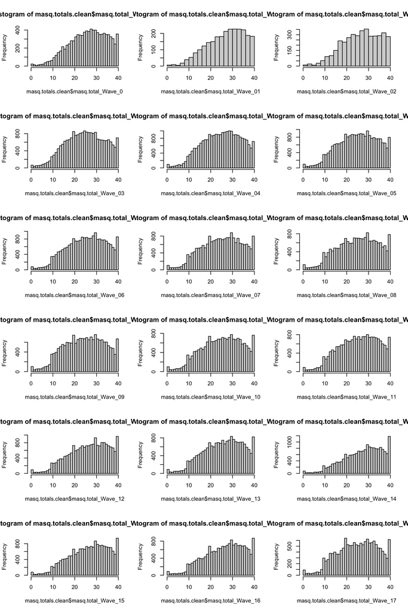

```r
layout(matrix(c(1:18), nrow=6, byrow=T))

hist(masq.totals.clean$masq.total_Wave_0, breaks="FD")
hist(masq.totals.clean$masq.total_Wave_01, breaks="FD")
hist(masq.totals.clean$masq.total_Wave_02, breaks="FD")

hist(masq.totals.clean$masq.total_Wave_03, breaks="FD")
hist(masq.totals.clean$masq.total_Wave_04, breaks="FD")
hist(masq.totals.clean$masq.total_Wave_05, breaks="FD")

hist(masq.totals.clean$masq.total_Wave_06, breaks="FD")
hist(masq.totals.clean$masq.total_Wave_07, breaks="FD")
hist(masq.totals.clean$masq.total_Wave_08, breaks="FD")

hist(masq.totals.clean$masq.total_Wave_09, breaks="FD")
hist(masq.totals.clean$masq.total_Wave_10, breaks="FD")
hist(masq.totals.clean$masq.total_Wave_11, breaks="FD")

hist(masq.totals.clean$masq.total_Wave_12, breaks="FD")
hist(masq.totals.clean$masq.total_Wave_13, breaks="FD")
hist(masq.totals.clean$masq.total_Wave_14, breaks="FD")

hist(masq.totals.clean$masq.total_Wave_15, breaks="FD")
hist(masq.totals.clean$masq.total_Wave_16, breaks="FD")
hist(masq.totals.clean$masq.total_Wave_17, breaks="FD")
```

```r
layout(1)
```